# NeuroBridge-S4: Proxy-Data Demonstration for Small-N Human Adaptation Management

**NeuroBridge-S4: A Small-N Human Adaptation Management Framework for Artemis II Proxy Data**

NASA Artemis II - Human Research Data Methodology Challenge

NeuroBridge-S4 is a methodology for converting sparse, high-dimensional, multimodal human spaceflight-like data into **individualized adaptation management profiles**. It is designed for the Artemis II small-N challenge: **n = 4**, multimodal measures, limited sampling, no conventional statistical power, and high value of each individual trajectory.

> **Central message.** NeuroBridge-S4 turns rare human spaceflight-like data from *"too small for conventional population statistics"* into *"deep enough for individualized biological interpretation and adaptation management."*

# Reviewer Quick Start

**Please read this first.** This notebook is written to be read like a report, top to bottom.

- This notebook demonstrates **NeuroBridge-S4** using **real public NHANES proxy data**.
- It does **not** use actual Artemis II astronaut data.
- It does **not** use synthetic subjects.
- **Four real NHANES participants** are selected as a real **n = 4 pseudo-crew**.
- The notebook has been **executed with outputs embedded**, so figures and tables are already visible.
- Reviewers can read it like a report from top to bottom.
- **Running the notebook is optional for review.** Reproducibility instructions are provided (see README).

### How to review this notebook in 10 minutes

1. Read **Reviewer Quick Start** and **Plain-language Project Summary**.
2. Inspect the **Control Ladder** and the **Outputs Index**.
3. Review the **reference deviation heatmap** and the **biological domain heatmap**.
4. Review **BACI** and the **BACI sensitivity** analysis.
5. Compare the **three graph types**: conceptual knowledge graph, observed proxy graph, and decision-support graph.
6. Read the **Individual Adaptation Profiles** and the **Crew-Level Summary**.
7. Use the **README** only if computational reproduction is desired.

# Plain-language Project Summary

NeuroBridge-S4 helps convert rare, small-sample human spaceflight-like data into **interpretable adaptation profiles**. Instead of asking whether four people can prove a population-level effect, the method asks what can be learned from **each individual's biological pattern** when it is compared with a real reference population and interpreted through **connected biological systems**.

**What the method is for:**

- to understand **which biological systems may be under strain**;
- to distinguish **isolated biomarker changes** from **coordinated multi-system patterns**;
- to help **prioritize what HRP may want to monitor next**.

**What the method is not for:**

- it is **not** intended to diagnose, and
- it is **not** intended to prescribe treatment.

Everything below builds toward a short, human-readable profile for each crew member and a crew-level summary that a human-research team could act on.

# Run Status

- **Last verified run:** top-to-bottom execution completed with **0 errors**.
- **Data source:** real **NHANES 2017-2018** public files downloaded directly from the CDC.
- **Download approach:** current CDC public data paths, with each file validated as a real SAS transport (`.xpt`) file by its header/magic bytes before use.
- **Internet required:** first run only (files are cached locally for fast, reproducible re-runs).
- **Synthetic subjects:** none.
- **Pseudo-crew:** real NHANES participants selected from the health-filtered terrestrial reference approximation.
- **Outputs generated:** figures (`.png`), data tables (`.csv`), and adaptation profile text reports (`.txt`).

**Latest run statistics**

| Metric | Value |
| --- | --- |
| Notebook cell count | 106 |
| Figures generated | 20 |
| Output tables / reports | 9 |
| Final reference cohort size | 996 participants |
| Pseudo-crew (anonymized SEQN) | 97774, 94465, 99813, 100987 |

# Outputs Index

Every result below is saved to `results/` (tables and reports) or `results/figures/` (figures), and is also embedded inline in this notebook.

| Output | File | Purpose | Where to inspect |
| --- | --- | --- | --- |
| Control Ladder | `figures/control_ladder.png` | How reference layers are stacked | Section 4 |
| Cohort filtering funnel | `figures/cohort_filtering_funnel.png` | How the reference cohort is built | Section 6 |
| Pseudo-crew overview | `figures/pseudo_crew_overview.png` | The four real participants | Section 7 |
| Reference deviation heatmap | `figures/reference_deviation_heatmap.png` | How unusual each member is | Section 8 |
| Biological domain heatmap | `figures/biological_domain_heatmap.png` | Strain by biological system | Section 9 |
| BACI bar chart | `figures/baci_scores.png` | Cross-system coherence score | Section 10 |
| BACI sensitivity | `figures/baci_sensitivity_analysis.png` | Robustness across thresholds | Section 11 |
| Biological knowledge graph | `figures/biological_knowledge_graph.png` | Conceptual system relationships | Section 12 |
| Observed proxy coherence graph | `figures/observed_proxy_coherence_graph.png` | Data-derived co-variation | Section 13 |
| Decision / management graph | `figures/decision_management_graph.png` | Pattern -> monitoring priority | Section 14 |
| Individual adaptation networks | `figures/individual_adaptation_network_*.png` | Each member as a system | Section 15 |
| Countermeasure priority map | `figures/countermeasure_priority_map.png` | Pattern -> support category | Section 16 |
| Acute cognitive-perceptual layer | `figures/acute_cognitive_perceptual_layer.png` | Conceptual monitoring flag | Section 20 |
| Artemis II translation map | `figures/artemis_translation_map.png` | Fit to Artemis II streams | Section 19 |
| Crew-level summary | `figures/crew_level_summary.png` / `crew_level_summary.csv` | Crew at a glance | Section 21 |
| Reference cohort summary | `reference_cohort_summary.csv` | Cohort statistics | Section 6 / export |
| Pseudo-crew table | `pseudo_crew.csv` | Crew measurements | Section 7 / export |
| Deviation scores | `deviation_scores.csv` | Per-member z-scores | Section 8 / export |
| Domain scores | `domain_scores.csv` | Per-member domain strain | Section 9 / export |
| BACI scores | `baci_scores.csv` | Coherence per member | Section 10 / export |
| BACI sensitivity table | `baci_sensitivity.csv` | BACI across thresholds | Section 11 / export |
| Layer value analysis | `layer_value_analysis.csv` | What each layer adds | Section 17 / export |
| Adaptation profiles | `adaptation_profiles.txt` | Human-readable reports | Section 18 |

# What HRP Gets from This Method

NeuroBridge-S4 produces a structured, reusable set of decision-support outputs:

- **Individual Adaptation Profiles** - one per crew member.
- **Cross-System Biological Coherence Maps** - which systems move together.
- **Crew-Level Adaptation Summary** - the crew at a glance, without averaging away individuals.
- **Recovery and Follow-Up Data Priorities** - what to measure next.
- **Monitoring Priority Matrix** - which systems deserve closer attention.
- **Countermeasure Consideration Map** - which support categories are relevant.
- **A reusable analytic workflow** for **Standard Measures, ARCHeR, and Immune Biomarkers**.

In operational terms, the method helps HRP ask and answer:

1. **What changed?**
2. **In which system?**
3. **Is the signal isolated or coherent across systems?**
4. **Is recovery progressing?**
5. **What should be monitored next?**
6. **Which countermeasure category should be considered?**

# Interpretation Guardrails

**Please keep these in mind while reviewing every figure and table.**

- **NHANES is used as a real terrestrial proxy reference dataset, not as a substitute for Artemis II.**
- NHANES is **not** true astronaut data; it is a **health-filtered terrestrial reference approximation**.
- The **n = 4 pseudo-crew are real participants**, not synthetic subjects.
- **BACI is a transparent signal-triage metric, not a validated diagnostic score.**
- Graphs are separated by type: **conceptual knowledge graph**, **data-derived observed proxy graph**, and **decision-support graph** - they must not be confused with one another.
- The notebook **does not diagnose** medical or psychiatric conditions.
- The notebook **does not prescribe treatment**.
- The correct interpretation of every output is: **"What systems should HRP look at more closely?"**

# Why Graph Representation Matters

Human adaptation is **relational**: sleep affects autonomic regulation, stress biology affects immune signaling, fatigue affects cognitive load. A flat table of biomarkers loses these connections. NeuroBridge-S4 therefore represents biomarkers, sleep, immune signals, cognitive load, and psychological indicators as **connected biological and functional systems**.

> **Tables break a human system into columns; graph representation helps assemble those columns back into a biological and operational system.**

NeuroBridge-S4 uses **three clearly distinct graph types**, and they must not be confused:

1. **Biological Knowledge Graph** *(Section 12)* - a **conceptual / literature-plausible** structure of how systems relate. It is **not** computed from NHANES and is **not** causal proof.
2. **Observed Proxy Coherence Graph** *(Section 13)* - **data-derived** relationships computed from the real proxy reference space. It shows co-variation, **not** causation.
3. **Decision / Management Graph** *(Section 14)* - a translation from biological pattern to **monitoring priority and countermeasure consideration**. It is an operational decision-support layer, **not** treatment guidance.

# 2. Why this notebook exists

Artemis II carries a **very small crew**. Conventional population-level statistics are weak when only four people are measured: there is no large astronaut control group, and a four-person study cannot prove population-level effects.

NeuroBridge-S4 deliberately changes the question.

- The purpose is **not** to prove population-level effects.
- The purpose is to extract **structured, biologically meaningful, operationally useful** information from **each individual**.
- NeuroBridge-S4 treats each crew member as a **longitudinal biological system**, not as one data point in a group.
- Proxy datasets act as a **reference coordinate system** - a way to ask "how unusual is this value?" - not as a replacement for Artemis II data.

# 3. Conceptual framework: from data to astronaut support

NeuroBridge-S4 organizes evidence into **four connected levels**. Lower levels are physical signals; higher levels are interpretations that those signals support.

**Level 1 - Physiological and behavioral signals:** sleep, activity, heart rate / heart-rate variability (HRV) where available, temperature, cardiovascular measures.

**Level 2 - Biochemical and immune processes:** stress hormones, inflammatory markers, immune shifts, metabolic regulation.

**Level 3 - Neurobiological and cognitive functional states:** autonomic regulation, circadian stability, arousal, recovery capacity, cognitive load.

**Level 4 - Evidence-based psychological and operational interpretation:** fatigue, workload tolerance, emotional regulation, stress perception, social/behavioral strain, recovery behavior.

The framework does **not** treat psychological states as isolated labels. It treats acute cognitive and psychological states as **emergent functional patterns** supported by *converging biological, behavioral, and validated self-report evidence*. A psychological interpretation is only considered when several independent measurements point the same way.

# 4. The Control Ladder

A single reference population is not enough, because astronauts are not an average sample of the public. NeuroBridge-S4 uses a **Control Ladder**: each reference source contributes at the level where it is scientifically strongest.

| Level | Reference source | Role |
| --- | --- | --- |
| **L1** | General healthy population reference | Broad biological variability |
| **L2** | Health-filtered terrestrial reference approximation | Closer comparison group |
| **L3** | Longitudinal wearable / sleep / stress proxy data | Time-resolved physiology |
| **L4** | Spaceflight analog / bedrest data | Spaceflight-like constraints |
| **L5** | Individual astronaut or pseudo-crew baseline | The person's own normal |

**In this notebook we implement Levels 1 and 2 using NHANES.** Levels 3-5 (wearables, analog/bedrest, and each astronaut's personal pre-flight baseline) would be added for full Artemis II work, using the same machinery. The figure below is generated by the code cell that follows.

*Technical cell: environment setup (libraries, reproducibility seed, output folders). Reviewers do not need to inspect this code unless verifying reproducibility.*

```python
# --- Setup: libraries, reproducibility, and output folders ---------------
import os
import io
import sys
import textwrap
import warnings
import urllib.request
from pathlib import Path

import numpy as np
import pandas as pd
import matplotlib
import matplotlib.pyplot as plt
from matplotlib.patches import FancyBboxPatch, FancyArrowPatch
import networkx as nx

warnings.filterwarnings("ignore")

# Reproducibility: a fixed seed makes pseudo-crew selection identical on every run.
RANDOM_SEED = 42
np.random.seed(RANDOM_SEED)

# Seaborn is used ONLY for styling, and ONLY if it is already installed.
try:
    import seaborn as sns
    sns.set_theme(style="whitegrid")
    HAVE_SEABORN = True
except Exception:
    HAVE_SEABORN = False

plt.rcParams.update({
    "figure.dpi": 110,
    "savefig.dpi": 150,
    "font.size": 11,
    "axes.titlesize": 13,
    "axes.titleweight": "bold",
})

# All saved files live under results/ ; all figures under results/figures/.
RESULTS = Path("results")
FIGURES = RESULTS / "figures"
CACHE = RESULTS / "nhanes_cache"
for _d in (RESULTS, FIGURES, CACHE):
    _d.mkdir(parents=True, exist_ok=True)

print("Environment ready.")
print(f"  numpy {np.__version__} | pandas {pd.__version__} | networkx {nx.__version__} | matplotlib {matplotlib.__version__}")
print(f"  seaborn styling available: {HAVE_SEABORN}")
print(f"  output directories: {RESULTS}/  and  {FIGURES}/")
print(f"  random seed: {RANDOM_SEED}")
```

```
Environment ready.
  numpy 2.4.6 | pandas 3.0.3 | networkx 3.6.1 | matplotlib 3.10.9
  seaborn styling available: False
  output directories: results/  and  results/figures/
  random seed: 42
```

*Technical cell: shared helper functions for saving figures and drawing heatmaps.*

```python
# --- Shared helper functions used throughout the notebook ---------------

def save_figure(fig, name):
    # Save a figure into results/figures/ and log the path.
    path = FIGURES / name
    fig.savefig(path, bbox_inches="tight", facecolor="white")
    print(f"  [saved figure] {path}")
    return path


def annotated_heatmap(ax, matrix, row_labels, col_labels, cmap="coolwarm",
                      vmin=None, vmax=None, fmt="{:.2f}", cbar_label=""):
    # A self-contained heatmap (matplotlib only) with numeric annotations.
    data = np.array(matrix, dtype=float)
    im = ax.imshow(data, cmap=cmap, vmin=vmin, vmax=vmax, aspect="auto")
    ax.set_xticks(range(len(col_labels)))
    ax.set_xticklabels(col_labels, rotation=45, ha="right")
    ax.set_yticks(range(len(row_labels)))
    ax.set_yticklabels(row_labels)
    for i in range(data.shape[0]):
        for j in range(data.shape[1]):
            v = data[i, j]
            if not np.isnan(v):
                ax.text(j, i, fmt.format(v), ha="center", va="center",
                        color="black", fontsize=9)
    cb = ax.figure.colorbar(im, ax=ax, fraction=0.046, pad=0.04)
    cb.set_label(cbar_label)
    return im

print("Helper functions defined: save_figure(), annotated_heatmap().")
```

```
Helper functions defined: save_figure(), annotated_heatmap().
```

*Technical cell: builds the Control Ladder figure shown above.*

```
  [saved figure] results/figures/control_ladder.png
```

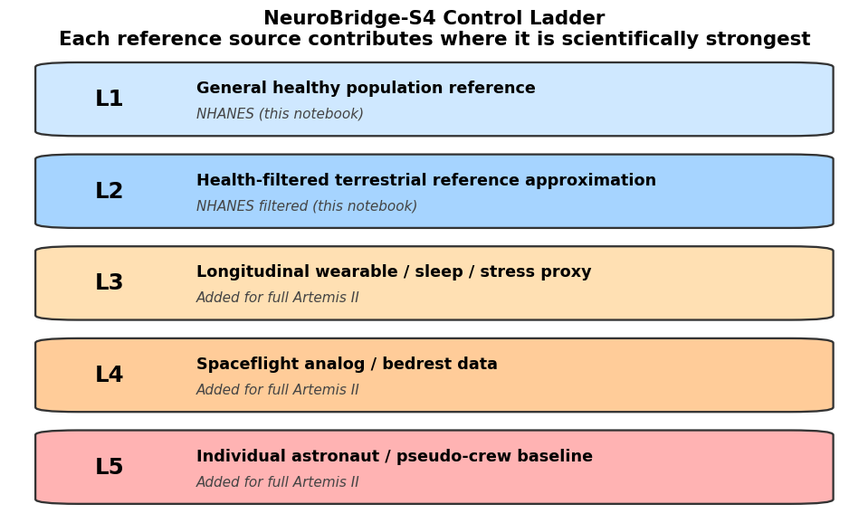

```python
# --- Figure: the Control Ladder ------------------------------------------
ladder = [
    ("L1", "General healthy population reference", "NHANES (this notebook)", "#cfe8ff"),
    ("L2", "Health-filtered terrestrial reference approximation", "NHANES filtered (this notebook)", "#a6d4ff"),
    ("L3", "Longitudinal wearable / sleep / stress proxy", "Added for full Artemis II", "#ffe0b3"),
    ("L4", "Spaceflight analog / bedrest data", "Added for full Artemis II", "#ffcc99"),
    ("L5", "Individual astronaut / pseudo-crew baseline", "Added for full Artemis II", "#ffb3b3"),
]

fig, ax = plt.subplots(figsize=(11, 6))
n = len(ladder)
for i, (lvl, label, status, color) in enumerate(ladder):
    y = n - 1 - i  # L1 at the bottom of the ladder
    box = FancyBboxPatch((0.05, y + 0.12), 0.9, 0.76,
                         boxstyle="round,pad=0.02,rounding_size=0.05",
                         linewidth=1.5, edgecolor="#333333", facecolor=color,
                         transform=ax.transData)
    ax.add_patch(box)
    ax.text(0.10, y + 0.5, lvl, fontsize=16, fontweight="bold", va="center")
    ax.text(0.22, y + 0.62, label, fontsize=11.5, fontweight="bold", va="center")
    ax.text(0.22, y + 0.34, status, fontsize=10, style="italic", color="#444444", va="center")

ax.set_xlim(0, 1)
ax.set_ylim(0, n)
ax.axis("off")
ax.set_title("NeuroBridge-S4 Control Ladder\nEach reference source contributes where it is scientifically strongest",
             fontsize=14)
save_figure(fig, "control_ladder.png")
plt.show()
```

**Reviewer note:**

- **What it shows:** the five reference layers NeuroBridge-S4 can use, from broad population data (L1) up to an astronaut's own baseline (L5).
- **Why it matters for HRP:** it makes explicit that NHANES is only the **lowest two rungs** - a reference approximation, not astronaut data.
- **Takeaway:** the same machinery climbs the ladder as real Artemis II data (wearables, analog, personal baseline) becomes available.

# 5. Load real NHANES public data

We now download **real public data** from the U.S. CDC's **National Health and Nutrition Examination Survey (NHANES)**, cycle **2017-2018**. NHANES is a large program that combines interviews, physical examinations, and laboratory tests on thousands of participants.

**Why NHANES is an appropriate proxy for this demonstration:**

- it is a **population-scale terrestrial reference space**;
- it provides **demographic, examination, and laboratory** data in one linkable system;
- it lets us build a **health-filtered terrestrial reference approximation** (a closer comparison group than the raw public sample);
- it supports **biomarker-based deviation analysis** across many biological systems.

**NHANES is not astronaut data and is not a substitute for Artemis II.** It is one lower rung of the Control Ladder. The loader is robust: each file is downloaded independently, validated as a real SAS transport (`.xpt`) file by its magic bytes, and cached locally; if any file is unavailable the notebook prints a friendly warning and continues.

*Technical cell: configuration - which NHANES files to load, the plain-English variable dictionary, and the biological domain map. Reviewers can skip the code; the variable dictionary is displayed in plain English further below.*

```python
# --- NHANES configuration -------------------------------------------------
NHANES_CYCLE = "2017-2018"
NHANES_YEAR = NHANES_CYCLE.split("-")[0]  # "2017"

# Files to load, with a plain-English description of each.
NHANES_FILES = {
    "DEMO_J.xpt":   "Demographics (age, sex, examination status)",
    "BMX_J.xpt":    "Body measures (BMI, waist, weight, height)",
    "BPX_J.xpt":    "Blood pressure and pulse",
    "GLU_J.xpt":    "Fasting plasma glucose",
    "TCHOL_J.xpt":  "Total cholesterol",
    "HDL_J.xpt":    "HDL ('good') cholesterol",
    "TRIGLY_J.xpt": "Triglycerides and LDL cholesterol",
    "CBC_J.xpt":    "Complete blood count (CBC)",
    "HSCRP_J.xpt":  "High-sensitivity C-reactive protein (inflammation)",
    "BIOPRO_J.xpt": "Standard biochemistry profile (albumin, creatinine, etc.)",
    "SMQ_J.xpt":    "Smoking questionnaire (used to keep non-smokers)",
}

# Variable dictionary: NHANES code -> (plain-English label, biological domain, unit).
VARIABLE_REGISTRY = {
    "RIDAGEYR": ("Age", "Demographics", "years"),
    "RIAGENDR": ("Sex (1=male, 2=female)", "Demographics", "code"),
    "BMXBMI":   ("Body Mass Index (BMI)", "Body composition / physical status", "kg/m^2"),
    "BMXWAIST": ("Waist circumference", "Body composition / physical status", "cm"),
    "BPXSY1":   ("Systolic blood pressure", "Cardiovascular regulation", "mmHg"),
    "BPXDI1":   ("Diastolic blood pressure", "Cardiovascular regulation", "mmHg"),
    "BPXPLS":   ("Resting pulse (60-second)", "Cardiovascular regulation", "beats/min"),
    "LBXGLU":   ("Fasting glucose", "Metabolic regulation", "mg/dL"),
    "LBXTC":    ("Total cholesterol", "Metabolic regulation", "mg/dL"),
    "LBDHDD":   ("HDL cholesterol", "Metabolic regulation", "mg/dL"),
    "LBXTR":    ("Triglycerides", "Metabolic regulation", "mg/dL"),
    "LBDLDL":   ("LDL cholesterol", "Metabolic regulation", "mg/dL"),
    "LBXHSCRP": ("High-sensitivity CRP", "Inflammation / immune-adjacent", "mg/L"),
    "LBXWBCSI": ("White blood cell count", "Inflammation / immune-adjacent", "1000 cells/uL"),
    "LBDLYMNO": ("Lymphocyte count", "Inflammation / immune-adjacent", "1000 cells/uL"),
    "LBDNENO":  ("Neutrophil count", "Inflammation / immune-adjacent", "1000 cells/uL"),
    "LBXHGB":   ("Hemoglobin", "Hematologic / oxygen-carrying", "g/dL"),
    "LBXHCT":   ("Hematocrit", "Hematologic / oxygen-carrying", "%"),
    "LBXRBCSI": ("Red blood cell count", "Hematologic / oxygen-carrying", "million cells/uL"),
    "LBXSAL":   ("Serum albumin", "Recovery-related markers", "g/dL"),
    "LBXSCR":   ("Serum creatinine", "Recovery-related markers", "mg/dL"),
    "LBXPLTSI": ("Platelet count", "Recovery-related markers", "1000 cells/uL"),
    "SMQ020":   ("Smoked >=100 cigarettes in life", "Lifestyle", "code"),
    "SMQ040":   ("Currently smokes", "Lifestyle", "code"),
}

# Numeric biomarker features grouped into biological domains (used for analysis).
DOMAIN_FEATURES = {
    "Cardiovascular regulation":          ["BPXSY1", "BPXDI1", "BPXPLS"],
    "Metabolic regulation":               ["LBXGLU", "LBXTC", "LBDHDD", "LBXTR", "LBDLDL"],
    "Body composition / physical status": ["BMXBMI", "BMXWAIST"],
    "Inflammation / immune-adjacent":     ["LBXHSCRP", "LBXWBCSI", "LBDLYMNO", "LBDNENO"],
    "Hematologic / oxygen-carrying":      ["LBXHGB", "LBXHCT", "LBXRBCSI"],
    "Recovery-related markers":           ["LBXSAL", "LBXSCR", "LBXPLTSI"],
}

print(f"Configured for NHANES cycle {NHANES_CYCLE}: {len(NHANES_FILES)} files, "
      f"{len(VARIABLE_REGISTRY)} catalogued variables, {len(DOMAIN_FEATURES)} biological domains.")
```

```
Configured for NHANES cycle 2017-2018: 11 files, 24 catalogued variables, 6 biological domains.
```

*Technical cell: robust downloader and loader (validates SAS XPT magic bytes; caches files). Reviewers can skip; the load results are summarized in the table below.*

```python
# --- Robust NHANES downloader --------------------------------------------
XPT_MAGIC = b"HEADER RECORD*"  # every valid SAS transport file starts with this


def candidate_urls(fname):
    # CDC has used more than one URL layout over time; try the known-good ones in order.
    return [
        f"https://wwwn.cdc.gov/Nchs/Data/Nhanes/Public/{NHANES_YEAR}/DataFiles/{fname}",
        f"https://wwwn.cdc.gov/Nchs/Data/Nhanes/Public/{NHANES_YEAR}/DataFiles/{fname.upper()}",
        f"https://wwwn.cdc.gov/Nchs/Nhanes/{NHANES_CYCLE}/{fname.upper()}",
    ]


def _download_bytes(url):
    # Prefer 'requests' (it ships trusted CA certificates via certifi); fall back to urllib.
    try:
        import requests
        resp = requests.get(url, headers={"User-Agent": "NeuroBridge-S4/1.0"}, timeout=120)
        resp.raise_for_status()
        return resp.content
    except ImportError:
        req = urllib.request.Request(url, headers={"User-Agent": "NeuroBridge-S4/1.0"})
        with urllib.request.urlopen(req, timeout=120) as resp:
            return resp.read()


def fetch_xpt(fname):
    # Return a DataFrame for one NHANES file, using a local cache when possible.
    cache_path = CACHE / fname
    if cache_path.exists() and cache_path.stat().st_size > 1000:
        with open(cache_path, "rb") as fh:
            if fh.read(len(XPT_MAGIC)) == XPT_MAGIC:
                return pd.read_sas(cache_path, format="xport")

    last_error = None
    for url in candidate_urls(fname):
        try:
            data = _download_bytes(url)
            if data[:len(XPT_MAGIC)] != XPT_MAGIC:
                last_error = f"content at {url} is not a SAS transport file (likely an HTML page)"
                continue
            cache_path.write_bytes(data)
            return pd.read_sas(io.BytesIO(data), format="xport")
        except Exception as exc:
            last_error = f"{type(exc).__name__}: {exc}"
            continue
    raise RuntimeError(last_error or "unknown download error")


# --- Load every file, recording success/failure --------------------------
loaded_tables = {}
load_log = []
for fname, desc in NHANES_FILES.items():
    try:
        df = fetch_xpt(fname)
        loaded_tables[fname] = df
        load_log.append({"file": fname, "description": desc, "status": "loaded",
                         "rows": df.shape[0], "columns": df.shape[1]})
        print(f"  [OK]   {fname:14s} {df.shape}  - {desc}")
    except Exception as exc:
        load_log.append({"file": fname, "description": desc, "status": "FAILED",
                         "rows": 0, "columns": 0})
        print(f"  [WARN] {fname:14s} could not be loaded: {exc}")
        print(f"         Continuing with the files that did load.")

DATA_AVAILABLE = "DEMO_J.xpt" in loaded_tables
load_log_df = pd.DataFrame(load_log)
print()
if DATA_AVAILABLE:
    print(f"Demographics loaded: real NHANES data is available. "
          f"{len(loaded_tables)}/{len(NHANES_FILES)} files loaded.")
else:
    print("STRUCTURE-ONLY FALLBACK: core demographics could not be downloaded.")
    print("No data will be fabricated. Re-run with internet access to reproduce the full demonstration.")
```

```
  [OK]   DEMO_J.xpt     (9254, 46)  - Demographics (age, sex, examination status)
  [OK]   BMX_J.xpt      (8704, 21)  - Body measures (BMI, waist, weight, height)
  [OK]   BPX_J.xpt      (8704, 21)  - Blood pressure and pulse
  [OK]   GLU_J.xpt      (3036, 4)  - Fasting plasma glucose
  [OK]   TCHOL_J.xpt    (7435, 3)  - Total cholesterol
  [OK]   HDL_J.xpt      (7435, 3)  - HDL ('good') cholesterol
  [OK]   TRIGLY_J.xpt   (3036, 10)  - Triglycerides and LDL cholesterol
  [OK]   CBC_J.xpt      (8366, 22)  - Complete blood count (CBC)
  [OK]   HSCRP_J.xpt    (8366, 3)  - High-sensitivity C-reactive protein (inflammation)
  [OK]   BIOPRO_J.xpt   (6401, 41)  - Standard biochemistry profile (albumin, creatinine, etc.)
  [OK]   SMQ_J.xpt      (6724, 37)  - Smoking questionnaire (used to keep non-smokers)

Demographics loaded: real NHANES data is available. 11/11 files loaded.
```

The table below records which files loaded. A few laboratory files cover only a fasting subsample, so their row counts are smaller than demographics - this is expected and handled gracefully.

```python
# --- Show the load log ----------------------------------------------------
from IPython.display import display
display(load_log_df)
```

|  | file | description | status | rows | columns |
| --- | --- | --- | --- | --- | --- |
| 0 | DEMO_J.xpt | Demographics (age, sex, examination status) | loaded | 9254 | 46 |
| 1 | BMX_J.xpt | Body measures (BMI, waist, weight, height) | loaded | 8704 | 21 |
| 2 | BPX_J.xpt | Blood pressure and pulse | loaded | 8704 | 21 |
| 3 | GLU_J.xpt | Fasting plasma glucose | loaded | 3036 | 4 |
| 4 | TCHOL_J.xpt | Total cholesterol | loaded | 7435 | 3 |
| 5 | HDL_J.xpt | HDL ('good') cholesterol | loaded | 7435 | 3 |
| 6 | TRIGLY_J.xpt | Triglycerides and LDL cholesterol | loaded | 3036 | 10 |
| 7 | CBC_J.xpt | Complete blood count (CBC) | loaded | 8366 | 22 |
| 8 | HSCRP_J.xpt | High-sensitivity C-reactive protein (inflammat... | loaded | 8366 | 3 |
| 9 | BIOPRO_J.xpt | Standard biochemistry profile (albumin, creati... | loaded | 6401 | 41 |
| 10 | SMQ_J.xpt | Smoking questionnaire (used to keep non-smokers) | loaded | 6724 | 37 |

*Technical cell: merge all files on the participant ID (SEQN) and keep examined participants.*

```python
# --- Merge all loaded files on the participant ID (SEQN) ------------------
if DATA_AVAILABLE:
    merged = loaded_tables["DEMO_J.xpt"][["SEQN", "RIDAGEYR", "RIAGENDR", "RIDSTATR"]].copy()
    for fname, df in loaded_tables.items():
        if fname == "DEMO_J.xpt":
            continue
        keep = [c for c in df.columns if c in VARIABLE_REGISTRY or c == "SEQN"]
        keep = list(dict.fromkeys(["SEQN"] + keep))  # SEQN first, de-duplicated
        merged = merged.merge(df[keep], on="SEQN", how="left")
    # Keep only participants who completed the examination (RIDSTATR == 2).
    merged = merged[merged["RIDSTATR"] == 2].drop(columns=["RIDSTATR"]).reset_index(drop=True)
    print(f"Merged dataset shape (participants x variables): {merged.shape}")
else:
    merged = pd.DataFrame(columns=["SEQN", "RIDAGEYR", "RIAGENDR"])
    print("Structure-only fallback: merged dataset is empty (no fabricated rows).")
```

```
Merged dataset shape (participants x variables): (8704, 25)
```

Below: a preview of the merged dataset, and a **variable dictionary** that translates the NHANES codes into plain English so a non-programmer reviewer can read every column.

```python
# --- Preview the merged dataset and build the variable dictionary --------
present_vars = [c for c in merged.columns if c in VARIABLE_REGISTRY]
preview_cols = ["SEQN"] + present_vars[:9]
print("Preview of the merged terrestrial reference dataset:")
display(merged[preview_cols].head(6))

dict_rows = []
for code_name in merged.columns:
    if code_name == "SEQN":
        dict_rows.append({"NHANES code": "SEQN", "Plain-English meaning": "Anonymized participant ID",
                          "Biological domain": "Identifier", "Unit": "-"})
    elif code_name in VARIABLE_REGISTRY:
        label, domain, unit = VARIABLE_REGISTRY[code_name]
        dict_rows.append({"NHANES code": code_name, "Plain-English meaning": label,
                          "Biological domain": domain, "Unit": unit})
variable_dictionary = pd.DataFrame(dict_rows)
print("\nVariable dictionary (plain-English meaning of every column):")
display(variable_dictionary)
```

```
Preview of the merged terrestrial reference dataset:
```

|  | SEQN | RIDAGEYR | RIAGENDR | BMXBMI | BMXWAIST | BPXPLS | BPXSY1 | BPXDI1 | LBXGLU | LBXTC |
| --- | --- | --- | --- | --- | --- | --- | --- | --- | --- | --- |
| 0 | 93703.0 | 2.0 | 2.0 | 17.5 | 48.2 | NaN | NaN | NaN | NaN | NaN |
| 1 | 93704.0 | 2.0 | 1.0 | 15.7 | 50.0 | NaN | NaN | NaN | NaN | NaN |
| 2 | 93705.0 | 66.0 | 2.0 | 31.7 | 101.8 | 52.0 | NaN | NaN | NaN | 157.0 |
| 3 | 93706.0 | 18.0 | 1.0 | 21.5 | 79.3 | 82.0 | 112.0 | 74.0 | NaN | 148.0 |
| 4 | 93707.0 | 13.0 | 1.0 | 18.1 | 64.1 | 100.0 | 128.0 | 38.0 | NaN | 189.0 |
| 5 | 93708.0 | 66.0 | 2.0 | 23.7 | 88.2 | 68.0 | NaN | NaN | 122.0 | 209.0 |

```
Variable dictionary (plain-English meaning of every column):
```

|  | NHANES code | Plain-English meaning | Biological domain | Unit |
| --- | --- | --- | --- | --- |
| 0 | SEQN | Anonymized participant ID | Identifier | - |
| 1 | RIDAGEYR | Age | Demographics | years |
| 2 | RIAGENDR | Sex (1=male, 2=female) | Demographics | code |
| 3 | BMXBMI | Body Mass Index (BMI) | Body composition / physical status | kg/m^2 |
| 4 | BMXWAIST | Waist circumference | Body composition / physical status | cm |
| 5 | BPXPLS | Resting pulse (60-second) | Cardiovascular regulation | beats/min |
| 6 | BPXSY1 | Systolic blood pressure | Cardiovascular regulation | mmHg |
| 7 | BPXDI1 | Diastolic blood pressure | Cardiovascular regulation | mmHg |
| 8 | LBXGLU | Fasting glucose | Metabolic regulation | mg/dL |
| 9 | LBXTC | Total cholesterol | Metabolic regulation | mg/dL |
| 10 | LBDHDD | HDL cholesterol | Metabolic regulation | mg/dL |
| 11 | LBXTR | Triglycerides | Metabolic regulation | mg/dL |
| 12 | LBDLDL | LDL cholesterol | Metabolic regulation | mg/dL |
| 13 | LBXWBCSI | White blood cell count | Inflammation / immune-adjacent | 1000 cells/uL |
| 14 | LBDLYMNO | Lymphocyte count | Inflammation / immune-adjacent | 1000 cells/uL |
| 15 | LBDNENO | Neutrophil count | Inflammation / immune-adjacent | 1000 cells/uL |
| 16 | LBXRBCSI | Red blood cell count | Hematologic / oxygen-carrying | million cells/uL |
| 17 | LBXHGB | Hemoglobin | Hematologic / oxygen-carrying | g/dL |
| 18 | LBXHCT | Hematocrit | Hematologic / oxygen-carrying | % |
| 19 | LBXPLTSI | Platelet count | Recovery-related markers | 1000 cells/uL |
| 20 | LBXHSCRP | High-sensitivity CRP | Inflammation / immune-adjacent | mg/L |
| 21 | LBXSAL | Serum albumin | Recovery-related markers | g/dL |
| 22 | LBXSCR | Serum creatinine | Recovery-related markers | mg/dL |
| 23 | SMQ020 | Smoked >=100 cigarettes in life | Lifestyle | code |
| 24 | SMQ040 | Currently smokes | Lifestyle | code |

**Reviewer note:**

- **What it shows:** the real, linked terrestrial dataset and a plain-English meaning for every column.
- **Why it matters for HRP:** this is the **reference coordinate system** - the population against which each pseudo-crew member is later compared.
- **Takeaway:** thousands of real people across cardiovascular, metabolic, body-composition, inflammation, hematologic, and recovery-related measures form the reference space - **not** Artemis II data, by design.

# 6. Build a health-filtered terrestrial reference approximation

Astronauts are **not** equivalent to the general population, so the raw NHANES sample is not the right comparison group. We build a **health-filtered terrestrial reference approximation**: a healthier adult subset with lower chronic-disease burden and complete measurements. This is an **approximation**, not astronaut-equivalent data. We are careful **not** to over-filter, so a large, stable reference group remains.

Filters applied (each only if its variable is available):

1. **Adults aged 30-60** - a realistic age band.
2. **Non-smokers** - excludes current smokers.
3. **Healthier metabolic/inflammatory profile** - operational BMI range, non-diabetic fasting glucose, no acute inflammation.
4. **Complete core measurements** - blood pressure and body measures present.
5. **Low overall missingness** - at least half of the analysis biomarkers present.

*Technical cell: cohort filtering. Each step records how many participants remain.*

```python
# --- Construct the health-filtered reference cohort, tracking each step ---
ANALYSIS_FEATURES = [f for feats in DOMAIN_FEATURES.values() for f in feats]
ANALYSIS_FEATURES = [f for f in ANALYSIS_FEATURES if f in merged.columns]

funnel = []
if DATA_AVAILABLE and len(merged) > 0:
    step = merged.copy()
    funnel.append(("All examined participants", len(step)))

    # 1. Adults aged 30-60
    step = step[step["RIDAGEYR"].between(30, 60)]
    funnel.append(("Adults aged 30-60", len(step)))

    # 2. Non-smokers (SMQ040: 1=every day, 2=some days are current smokers)
    if "SMQ040" in step.columns:
        current_smoker = step["SMQ040"].isin([1, 2])
        step = step[~current_smoker]
        funnel.append(("Non-smokers", len(step)))

    # 3. Healthier metabolic / inflammatory profile
    healthier = pd.Series(True, index=step.index)
    if "BMXBMI" in step.columns:
        healthier &= step["BMXBMI"].between(18.5, 32) | step["BMXBMI"].isna()
    if "LBXGLU" in step.columns:
        healthier &= (step["LBXGLU"] < 126) | step["LBXGLU"].isna()
    if "LBXHSCRP" in step.columns:
        healthier &= (step["LBXHSCRP"] < 10) | step["LBXHSCRP"].isna()
    step = step[healthier]
    funnel.append(("Healthier metabolic/inflammatory profile", len(step)))

    # 4. Complete core measurements: blood pressure and body measures present
    core = [c for c in ["BPXSY1", "BPXDI1", "BMXBMI"] if c in step.columns]
    if core:
        step = step.dropna(subset=core)
    funnel.append(("Complete core measurements", len(step)))

    # 5. Low overall missingness across analysis biomarkers
    if ANALYSIS_FEATURES:
        frac_present = step[ANALYSIS_FEATURES].notna().mean(axis=1)
        step = step[frac_present >= 0.5]
    funnel.append(("Health-filtered reference cohort", len(step)))

    reference_cohort = step.reset_index(drop=True)
else:
    reference_cohort = merged.copy()
    funnel.append(("Health-filtered reference cohort", len(reference_cohort)))

funnel_df = pd.DataFrame(funnel, columns=["Filtering step", "Participants remaining"])
print("Cohort filtering funnel:")
display(funnel_df)
print(f"\nHealth-filtered reference cohort size: {len(reference_cohort)} real participants.")
```

```
Cohort filtering funnel:
```

|  | Filtering step | Participants remaining |
| --- | --- | --- |
| 0 | All examined participants | 8704 |
| 1 | Adults aged 30-60 | 2607 |
| 2 | Non-smokers | 2032 |
| 3 | Healthier metabolic/inflammatory profile | 1207 |
| 4 | Complete core measurements | 1049 |
| 5 | Health-filtered reference cohort | 996 |

```
Health-filtered reference cohort size: 996 real participants.
```

```
  [saved figure] results/figures/cohort_filtering_funnel.png
```

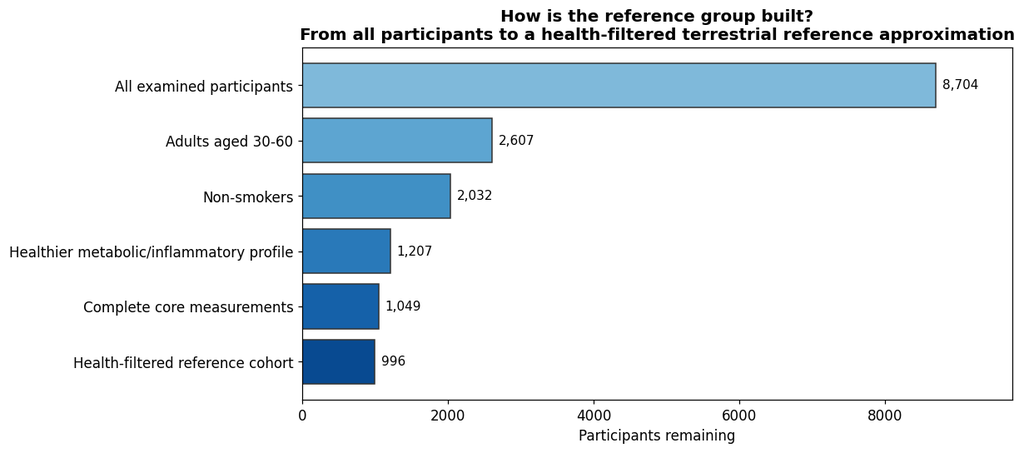

```python
# --- Figure: cohort filtering funnel -------------------------------------
fig, ax = plt.subplots(figsize=(10, 5))
labels = funnel_df["Filtering step"].tolist()
values = funnel_df["Participants remaining"].tolist()
ypos = range(len(labels))
colors = plt.cm.Blues(np.linspace(0.45, 0.9, len(labels)))
bars = ax.barh(list(ypos), values, color=colors, edgecolor="#333333")
ax.set_yticks(list(ypos))
ax.set_yticklabels(labels)
ax.invert_yaxis()
ax.set_xlabel("Participants remaining")
ax.set_title("How is the reference group built?\nFrom all participants to a health-filtered terrestrial reference approximation")
for bar, v in zip(bars, values):
    ax.text(bar.get_width() + max(values) * 0.01, bar.get_y() + bar.get_height() / 2,
            f"{v:,}", va="center", fontsize=10)
ax.margins(x=0.12)
save_figure(fig, "cohort_filtering_funnel.png")
plt.show()
```

**Reviewer note:**

- **What it shows:** how a large public sample is narrowed, step by step, into a healthier reference group.
- **Why it matters for HRP:** pseudo-crew members must be compared to a **relevant** reference space, not an arbitrary population.
- **Takeaway:** filtering is disciplined but not aggressive - a large, stable reference group remains, while staying an approximation rather than astronaut-equivalent data.

# 7. Select a real n = 4 pseudo-crew

The pseudo-crew is **not synthetic**. It is **four real NHANES participants** drawn from the health-filtered reference cohort. This deliberately recreates the Artemis II statistical challenge: **only four people, but many measurements each**. To keep the comparison honest, the four members are **withheld** from the reference distribution used for scoring, and are identified only by their anonymized NHANES sequence number (SEQN).

*Technical cell: pseudo-crew selection (fixed random seed for reproducibility).*

```python
# --- Select four real participants as the pseudo-crew --------------------
PSEUDO_CREW_N = 4

if len(reference_cohort) >= PSEUDO_CREW_N:
    rng = np.random.default_rng(RANDOM_SEED)
    crew_idx = rng.choice(reference_cohort.index, size=PSEUDO_CREW_N, replace=False)
    pseudo_crew = reference_cohort.loc[crew_idx].reset_index(drop=True)
    # Withhold the crew from the reference distribution used for scoring.
    reference_pool = reference_cohort.drop(index=crew_idx).reset_index(drop=True)
    pseudo_crew["SEQN"] = pseudo_crew["SEQN"].astype(int)
    crew_ids = pseudo_crew["SEQN"].tolist()
    print(f"Selected {PSEUDO_CREW_N} real pseudo-crew participants (anonymized SEQN): {crew_ids}")
    print(f"Reference pool used for scoring (crew withheld): {len(reference_pool)} participants")
else:
    pseudo_crew = reference_cohort.copy()
    reference_pool = reference_cohort.copy()
    crew_ids = pseudo_crew["SEQN"].astype(int).tolist() if len(pseudo_crew) else []
    print("Structure-only fallback: not enough participants to form a pseudo-crew.")

# Compact, non-identifying feature table for the crew.
crew_display_cols = ["SEQN"] + [c for c in ["RIDAGEYR", "RIAGENDR", "BMXBMI", "BPXSY1",
                     "BPXDI1", "BPXPLS", "LBXGLU", "LBXHSCRP"] if c in pseudo_crew.columns]
print("\nPseudo-crew overview (real measurements, no personal identifiers):")
display(pseudo_crew[crew_display_cols])
```

```
Selected 4 real pseudo-crew participants (anonymized SEQN): [97774, 94465, 99813, 100987]
Reference pool used for scoring (crew withheld): 992 participants

Pseudo-crew overview (real measurements, no personal identifiers):
```

|  | SEQN | RIDAGEYR | RIAGENDR | BMXBMI | BPXSY1 | BPXDI1 | BPXPLS | LBXGLU | LBXHSCRP |
| --- | --- | --- | --- | --- | --- | --- | --- | --- | --- |
| 0 | 97774 | 33.0 | 1.0 | 20.3 | 128.0 | 74.0 | 80.0 | 109.0 | 0.36 |
| 1 | 94465 | 31.0 | 1.0 | 30.9 | 124.0 | 60.0 | 56.0 | NaN | 0.57 |
| 2 | 99813 | 48.0 | 1.0 | 25.8 | 124.0 | 76.0 | 68.0 | NaN | 7.02 |
| 3 | 100987 | 60.0 | 1.0 | 28.9 | 152.0 | 98.0 | 88.0 | NaN | 1.27 |

```
  [saved figure] results/figures/pseudo_crew_overview.png
```

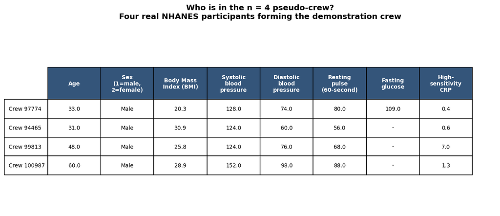

```python
# --- Figure: pseudo-crew overview as a clean table -----------------------
if len(pseudo_crew) > 0:
    table_cols = [c for c in crew_display_cols if c != "SEQN"]
    col_labels = [VARIABLE_REGISTRY.get(c, (c,))[0] for c in table_cols]
    cell_text = []
    row_labels = []
    for _, row in pseudo_crew.iterrows():
        row_labels.append(f"Crew {int(row['SEQN'])}")
        vals = []
        for c in table_cols:
            v = row[c]
            if c == "RIAGENDR" and not pd.isna(v):
                vals.append("Male" if int(v) == 1 else "Female")
            else:
                vals.append("-" if pd.isna(v) else f"{v:.1f}")
        cell_text.append(vals)

    fig, ax = plt.subplots(figsize=(14, 3.4 + 0.5 * len(pseudo_crew)))
    ax.axis("off")
    wrapped_labels = ["\n".join(textwrap.wrap(lbl, 11)) for lbl in col_labels]
    ncol = len(col_labels)
    tbl = ax.table(cellText=cell_text, rowLabels=row_labels, colLabels=wrapped_labels,
                   cellLoc="center", loc="center", colWidths=[0.9 / ncol] * ncol)
    tbl.auto_set_font_size(False)
    tbl.set_fontsize(9)
    tbl.scale(1, 2.6)
    for j in range(len(col_labels)):
        tbl[0, j].set_facecolor("#34557a")
        tbl[0, j].set_text_props(color="white", fontweight="bold")
        tbl[0, j].set_height(tbl[0, j].get_height() * 1.7)
    ax.set_title("Who is in the n = 4 pseudo-crew?\nFour real NHANES participants forming the demonstration crew",
                 fontsize=13, pad=20)
    save_figure(fig, "pseudo_crew_overview.png")
    plt.show()
```

**Reviewer note:**

- **What it shows:** the four real people who serve as real proxy-data participants used to recreate the n=4 structure of the Artemis II challenge, with a few key measurements.
- **Why it matters for HRP:** it makes the small-N constraint concrete - four individuals, each analyzed on their own.
- **Takeaway:** these are **real participants, not synthetic subjects**, withheld from the reference pool to keep the comparison fair.

# 8. Create reference deviation scores

Raw biomarkers use different units (mg/dL, mmHg, g/dL, ...), so they cannot be compared directly. NeuroBridge-S4 converts each value into a **reference deviation score** that answers a single plain-English question:

> *"How unusual is this participant's value compared with the health-filtered reference cohort?"*

For each feature we compute the reference mean and standard deviation from the **reference pool** (crew withheld), then for each crew member: `z = (the person's value - reference mean) / reference standard deviation`. A z near 0 means "typical for this cohort"; a large positive or negative z means "unusual - worth a closer look." We deliberately call these **reference deviations**, never "abnormal" and never diagnostic.

*Technical cell: reference deviation (z-score) computation.*

```python
# --- Compute reference deviation (z) scores for the pseudo-crew ----------
MIN_REF_N = 50  # minimum non-missing reference values required to score a feature

scored_features = []
ref_stats = {}
for feat in ANALYSIS_FEATURES:
    ref_vals = reference_pool[feat].dropna() if feat in reference_pool.columns else pd.Series(dtype=float)
    if len(ref_vals) >= MIN_REF_N and ref_vals.std(ddof=0) > 0:
        ref_stats[feat] = {"mean": ref_vals.mean(), "std": ref_vals.std(ddof=0),
                           "values": ref_vals.values}
        scored_features.append(feat)

deviation_rows = {}
percentile_rows = {}
for _, member in pseudo_crew.iterrows():
    seqn = int(member["SEQN"])
    z_scores, pcts = {}, {}
    for feat in scored_features:
        val = member[feat]
        if pd.isna(val):
            z_scores[feat], pcts[feat] = np.nan, np.nan
        else:
            s = ref_stats[feat]
            z_scores[feat] = (val - s["mean"]) / s["std"]
            pcts[feat] = float((s["values"] < val).mean() * 100.0)
    deviation_rows[f"Crew {seqn}"] = z_scores
    percentile_rows[f"Crew {seqn}"] = pcts

deviation_scores = pd.DataFrame(deviation_rows).T
percentile_scores = pd.DataFrame(percentile_rows).T
deviation_scores.columns = [VARIABLE_REGISTRY.get(c, (c,))[0] for c in deviation_scores.columns]

print(f"Scored {len(scored_features)} biomarkers with sufficient reference data.")
print("\nReference deviation (z-score) table:")
display(deviation_scores.round(2))
```

```
Scored 20 biomarkers with sufficient reference data.

Reference deviation (z-score) table:
```

|  | Systolic blood pressure | Diastolic blood pressure | Resting pulse (60-second) | Fasting glucose | Total cholesterol | HDL cholesterol | Triglycerides | LDL cholesterol | Body Mass Index (BMI) | Waist circumference | High-sensitivity CRP | White blood cell count | Lymphocyte count | Neutrophil count | Hemoglobin | Hematocrit | Red blood cell count | Serum albumin | Serum creatinine | Platelet count |
| --- | --- | --- | --- | --- | --- | --- | --- | --- | --- | --- | --- | --- | --- | --- | --- | --- | --- | --- | --- | --- |
| Crew 97774 | 0.49 | -0.05 | 0.91 | 0.94 | -0.45 | 0.25 | 0.12 | -0.67 | -1.87 | -1.86 | -0.86 | -0.17 | -0.53 | 0.13 | 2.14 | 2.24 | 1.94 | 1.87 | -0.90 | 0.06 |
| Crew 94465 | 0.24 | -1.26 | -1.35 | NaN | 0.88 | 0.79 | NaN | NaN | 1.39 | 1.25 | -0.74 | 0.21 | -0.69 | 0.34 | 0.58 | 0.59 | 0.71 | -0.75 | 0.92 | 0.75 |
| Crew 99813 | 0.24 | 0.12 | -0.22 | NaN | 1.54 | -0.78 | NaN | NaN | -0.18 | 0.21 | 2.69 | 0.65 | -0.22 | 0.83 | 0.45 | 0.50 | 1.16 | NaN | NaN | 0.84 |
| Crew 100987 | 1.96 | 2.01 | 1.67 | NaN | -0.30 | -1.08 | NaN | NaN | 0.78 | 0.56 | -0.37 | 0.49 | 0.89 | 0.20 | 0.58 | 0.35 | 0.91 | 0.56 | -0.12 | -1.44 |

```
  [saved figure] results/figures/reference_deviation_heatmap.png
```

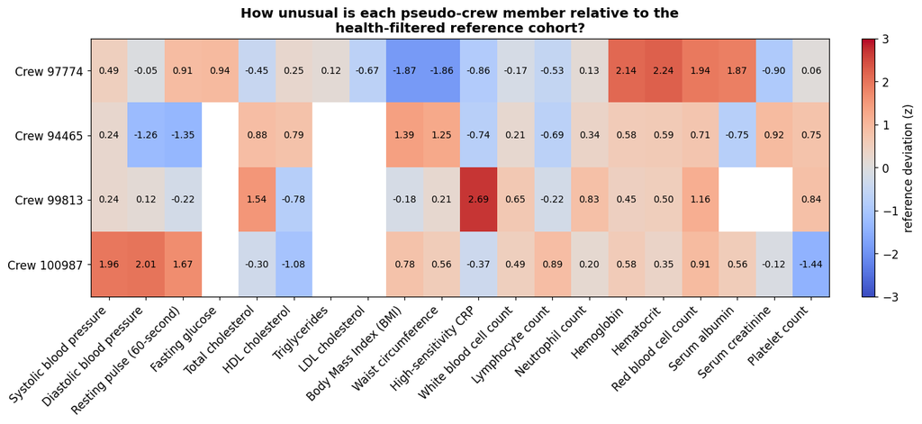

```python
# --- Figure: reference deviation heatmap ---------------------------------
if not deviation_scores.empty:
    fig, ax = plt.subplots(figsize=(max(10, 0.7 * deviation_scores.shape[1]), 4.5))
    annotated_heatmap(ax, deviation_scores.values,
                      row_labels=deviation_scores.index.tolist(),
                      col_labels=deviation_scores.columns.tolist(),
                      cmap="coolwarm", vmin=-3, vmax=3,
                      cbar_label="reference deviation (z)")
    ax.set_title("How unusual is each pseudo-crew member relative to the\nhealth-filtered reference cohort?")
    save_figure(fig, "reference_deviation_heatmap.png")
    plt.show()
```

**Reviewer note:**

- **What it shows:** red cells are above the reference average, blue cells below; deep colors mark the most distinct values.
- **Why it matters for HRP:** with only four people, this pinpoints *which specific measurements* make each individual stand out - far more useful than a group average.
- **Takeaway:** these are **relative-unusualness** scores against a reference space, not statements that anything is abnormal.

# 9. Map features into biological domains

A single biomarker is rarely meaningful on its own. NeuroBridge-S4 groups variables into **biological domains** so that reviewers can interpret **systems**, not scattered numbers. For each crew member we compute the **mean absolute deviation** within each domain - a compact measure of "how strained is this whole system?"

*Technical cell: domain-level aggregation of deviation scores.*

```python
# --- Compute mean absolute deviation per biological domain ---------------
present_domains = {}
for domain, feats in DOMAIN_FEATURES.items():
    feats_present = [f for f in feats if f in scored_features]
    if feats_present:
        present_domains[domain] = feats_present

domain_rows = {}
for member_label in deviation_scores.index:
    # work from the un-relabeled z-scores so we can index by NHANES code
    seqn = int(member_label.split()[1])
    member = pseudo_crew[pseudo_crew["SEQN"] == seqn].iloc[0]
    row = {}
    for domain, feats in present_domains.items():
        zs = []
        for f in feats:
            val = member[f]
            if not pd.isna(val):
                s = ref_stats[f]
                zs.append(abs((val - s["mean"]) / s["std"]))
        row[domain] = float(np.mean(zs)) if zs else np.nan
    domain_rows[member_label] = row

domain_scores = pd.DataFrame(domain_rows).T
print("Mean absolute reference deviation by biological domain:")
display(domain_scores.round(2))
```

```
Mean absolute reference deviation by biological domain:
```

|  | Cardiovascular regulation | Metabolic regulation | Body composition / physical status | Inflammation / immune-adjacent | Hematologic / oxygen-carrying | Recovery-related markers |
| --- | --- | --- | --- | --- | --- | --- |
| Crew 97774 | 0.48 | 0.49 | 1.87 | 0.42 | 2.11 | 0.94 |
| Crew 94465 | 0.95 | 0.84 | 1.32 | 0.50 | 0.63 | 0.81 |
| Crew 99813 | 0.19 | 1.16 | 0.19 | 1.10 | 0.70 | 0.84 |
| Crew 100987 | 1.88 | 0.69 | 0.67 | 0.49 | 0.61 | 0.71 |

```
  [saved figure] results/figures/biological_domain_heatmap.png
```

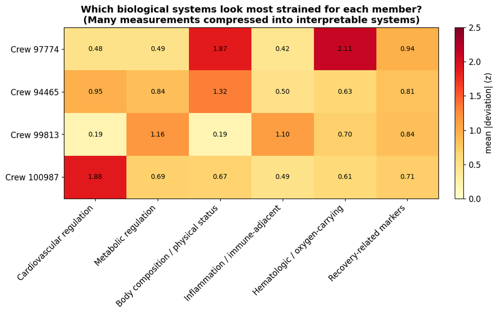

```python
# --- Figure: biological domain heatmap -----------------------------------
if not domain_scores.empty:
    fig, ax = plt.subplots(figsize=(10, 4.2))
    annotated_heatmap(ax, domain_scores.values,
                      row_labels=domain_scores.index.tolist(),
                      col_labels=domain_scores.columns.tolist(),
                      cmap="YlOrRd", vmin=0, vmax=max(2.5, np.nanmax(domain_scores.values)),
                      cbar_label="mean |deviation| (z)")
    ax.set_title("Which biological systems look most strained for each member?\n(Many measurements compressed into interpretable systems)")
    save_figure(fig, "biological_domain_heatmap.png")
    plt.show()
```

**Reviewer note:**

- **What it shows:** many individual measurements compressed into a handful of biological **systems**, per member.
- **Why it matters for HRP:** reviewers can see at a glance whether a member's signal concentrates in (e.g.) cardiovascular regulation or inflammation.
- **Takeaway:** this is the first step from scattered numbers toward deciding **what to monitor and support**.

# 10. BACI: the Biological Adaptation Coherence Index

**BACI = Biological Adaptation Coherence Index.** It is a **transparent signal-triage metric**, not a diagnosis and not a validated clinical score. It asks one operationally useful question:

> *"Are multiple biological domains shifting together strongly enough to justify closer review?"*

The logic is conservative: an **isolated** biomarker change is weak evidence, while a **coordinated, multi-domain** shift is more meaningful. BACI is computed transparently from quantities you can see in the tables above and normalized to **0-100**. It reflects:

- **breadth** - the number of shifted domains (mean |z| above a threshold);
- **magnitude** - how large those shifts are;
- **spread** - whether shifts span several independent biological systems;
- *(and, in future longitudinal Artemis II use, **temporal alignment** and **recovery delay**).*

| BACI | Category |
| --- | --- |
| 0-25 | low coherence |
| 25-50 | mild coherence |
| 50-75 | moderate coherence |
| 75-100 | high coherence |

*Technical cell: BACI is defined as a small, readable function so it can be re-run at several thresholds (Section 11).*

```python
# --- Compute BACI for each pseudo-crew member ----------------------------
SHIFT_THRESHOLD = 1.0  # a domain is 'shifted' when mean |z| exceeds this


def classify_baci(score):
    if score < 25:
        return "low coherence"
    if score < 50:
        return "mild coherence"
    if score < 75:
        return "moderate coherence"
    return "high coherence"


def compute_baci(threshold):
    # Transparent signal-triage score in 0-100, combining breadth, magnitude, and spread.
    rows = []
    n_dom = domain_scores.shape[1] if not domain_scores.empty else 0
    for member_label, row in domain_scores.iterrows():
        vals = row.dropna()
        if len(vals) == 0 or n_dom == 0:
            rows.append({"crew": member_label, "BACI": 0.0, "category": "low coherence",
                         "shifted_domains": 0})
            continue
        shifted = vals[vals >= threshold]
        breadth = len(shifted) / n_dom
        magnitude = float(np.clip((shifted.mean() if len(shifted) else vals.mean()) / 3.0, 0, 1))
        spread = float(np.clip((len(shifted) - 1) / max(n_dom - 1, 1), 0, 1)) if len(shifted) else 0.0
        raw = 0.40 * breadth + 0.35 * magnitude + 0.25 * spread
        score = round(100.0 * raw, 1)
        rows.append({"crew": member_label, "BACI": score, "category": classify_baci(score),
                     "shifted_domains": int(len(shifted))})
    if not rows:
        out = pd.DataFrame(columns=["BACI", "category", "shifted_domains"])
        out.index.name = "crew"
        return out
    return pd.DataFrame(rows).set_index("crew")


baci_scores = compute_baci(SHIFT_THRESHOLD)
print(f"Biological Adaptation Coherence Index (BACI) at threshold {SHIFT_THRESHOLD}:")
display(baci_scores)
```

```
Biological Adaptation Coherence Index (BACI) at threshold 1.0:
```

| crew | BACI | category | shifted_domains |
| --- | --- | --- | --- |
| Crew 97774 | 41.5 | mild coherence | 2 |
| Crew 94465 | 22.1 | low coherence | 1 |
| Crew 99813 | 31.5 | mild coherence | 2 |
| Crew 100987 | 28.6 | mild coherence | 1 |

```
  [saved figure] results/figures/baci_scores.png
```

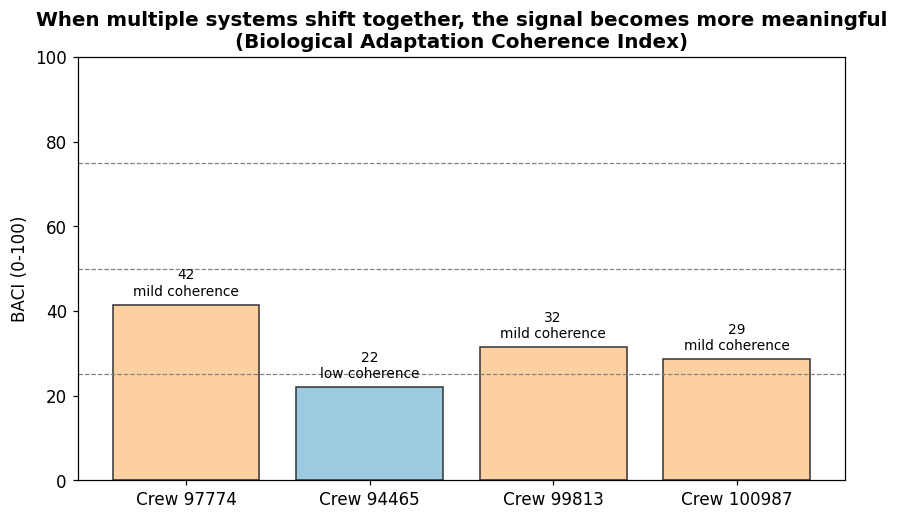

```
Most coordinated multi-domain signal: Crew 97774 (BACI = 42, mild coherence, 2 shifted domains).
```

```python
# --- Figure: BACI bar chart ----------------------------------------------
cat_color = {"low coherence": "#9ecae1", "mild coherence": "#fdd0a2",
             "moderate coherence": "#fd8d3c", "high coherence": "#d7301f"}
if not baci_scores.empty:
    fig, ax = plt.subplots(figsize=(9, 5))
    colors = [cat_color[c] for c in baci_scores["category"]]
    bars = ax.bar(baci_scores.index, baci_scores["BACI"], color=colors, edgecolor="#333333")
    for thr in (25, 50, 75):
        ax.axhline(thr, color="grey", linestyle="--", linewidth=0.8)
    ax.set_ylim(0, 100)
    ax.set_ylabel("BACI (0-100)")
    ax.set_title("When multiple systems shift together, the signal becomes more meaningful\n(Biological Adaptation Coherence Index)")
    for bar, (label, r) in zip(bars, baci_scores.iterrows()):
        ax.text(bar.get_x() + bar.get_width() / 2, bar.get_height() + 1.5,
                f"{r['BACI']:.0f}\n{r['category']}", ha="center", va="bottom", fontsize=9)
    save_figure(fig, "baci_scores.png")
    plt.show()

if not baci_scores.empty:
    top_member = baci_scores["BACI"].idxmax()
    print(f"Most coordinated multi-domain signal: {top_member} "
          f"(BACI = {baci_scores.loc[top_member, 'BACI']:.0f}, "
          f"{baci_scores.loc[top_member, 'category']}, "
          f"{int(baci_scores.loc[top_member, 'shifted_domains'])} shifted domains).")
```

**Reviewer note:**

- **What it shows:** how coherent each member's multi-system signal is, on a 0-100 triage scale.
- **Why it matters for HRP:** it separates "one odd number" from "several systems moving together," which deserves closer review.
- **Takeaway:** BACI is a **prioritization aid**, not a diagnosis; higher scores simply mean "look here first."

# 11. BACI sensitivity analysis

A triage metric is only trustworthy if it is **not fragile**. Here we recompute BACI at three "shift" thresholds - **0.75, 1.00, and 1.25** - and check whether the ranking of crew members stays stable.

- If the ranking is **stable**, this supports the robustness of the signal-triage logic.
- If the ranking **changes**, this reveals threshold sensitivity that HRP experts should review.

*Technical cell: recompute BACI across thresholds and assess ranking stability.*

```python
# --- BACI sensitivity across thresholds ----------------------------------
THRESHOLDS = [0.75, 1.00, 1.25]
sens_rows = []
rankings = {}
for t in THRESHOLDS:
    b = compute_baci(t)
    rankings[t] = list(b["BACI"].sort_values(ascending=False).index)
    for crew_label, r in b.iterrows():
        sens_rows.append({"participant": crew_label, "threshold": t,
                          "BACI": r["BACI"], "category": r["category"]})

baci_sensitivity = pd.DataFrame(sens_rows)
baci_sensitivity.to_csv(RESULTS / "baci_sensitivity.csv", index=False)
print("BACI across thresholds:")
display(baci_sensitivity.pivot(index="participant", columns="threshold", values="BACI"))

ranking_stable = all(rankings[THRESHOLDS[0]] == rankings[t] for t in THRESHOLDS)
print(f"\nRanking identical across all thresholds: {ranking_stable}")
if ranking_stable:
    print("  -> Interpretation: the signal-triage ranking is robust to threshold choice.")
else:
    print("  -> Interpretation: ranking shifts with threshold; HRP experts should review borderline members.")
```

```
BACI across thresholds:
```

| threshold participant | 0.75 | 1.00 | 1.25 |
| --- | --- | --- | --- |
| Crew 100987 | 28.6 | 28.6 | 28.6 |
| Crew 94465 | 53.1 | 22.1 | 22.1 |
| Crew 97774 | 49.1 | 41.5 | 41.5 |
| Crew 99813 | 42.0 | 31.5 | 8.1 |

```
Ranking identical across all thresholds: False
  -> Interpretation: ranking shifts with threshold; HRP experts should review borderline members.
```

```
  [saved figure] results/figures/baci_sensitivity_analysis.png
```

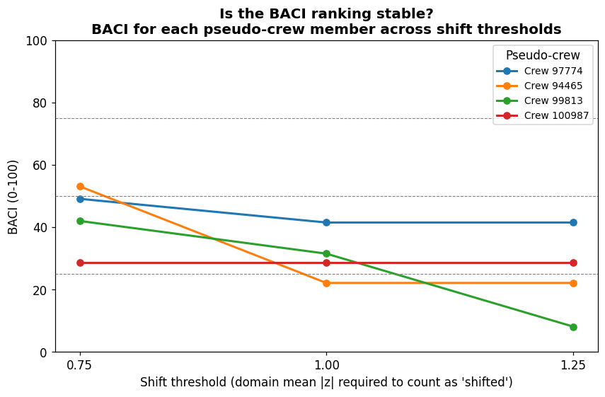

```python
# --- Figure: BACI sensitivity --------------------------------------------
if not baci_sensitivity.empty:
    fig, ax = plt.subplots(figsize=(9, 5.2))
    for crew_label in baci_sensitivity["participant"].unique():
        sub = baci_sensitivity[baci_sensitivity["participant"] == crew_label].sort_values("threshold")
        ax.plot(sub["threshold"], sub["BACI"], marker="o", linewidth=2, label=crew_label)
    for thr in (25, 50, 75):
        ax.axhline(thr, color="grey", linestyle="--", linewidth=0.7)
    ax.set_xticks(THRESHOLDS)
    ax.set_ylim(0, 100)
    ax.set_xlabel("Shift threshold (domain mean |z| required to count as 'shifted')")
    ax.set_ylabel("BACI (0-100)")
    ax.set_title("Is the BACI ranking stable?\nBACI for each pseudo-crew member across shift thresholds")
    ax.legend(title="Pseudo-crew", fontsize=9)
    save_figure(fig, "baci_sensitivity_analysis.png")
    plt.show()
```

# 12. Biological Knowledge Graph (conceptual)

**This is graph type 1 of 3: a conceptual graph.** It represents **literature-plausible** biological and operational relationships used for interpretation. It is **not computed from NHANES** and is **not** causal proof. It is the scientific map that connects biochemistry, neurobiology, cognitive function, evidence-based psychology, and the operational endpoints (monitoring priority and countermeasure consideration).

*Technical cell: builds the conceptual knowledge graph with networkx.*

```
  [saved figure] results/figures/biological_knowledge_graph.png
```

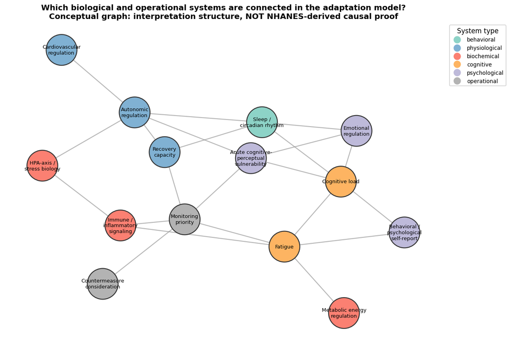

```python
# --- Build and draw the conceptual biological knowledge graph ------------
KNOWLEDGE_NODES = {
    "Sleep / circadian rhythm": "behavioral",
    "Autonomic regulation": "physiological",
    "HPA-axis / stress biology": "biochemical",
    "Immune / inflammatory signaling": "biochemical",
    "Metabolic energy regulation": "biochemical",
    "Cardiovascular regulation": "physiological",
    "Cognitive load": "cognitive",
    "Fatigue": "cognitive",
    "Emotional regulation": "psychological",
    "Acute cognitive-perceptual vulnerability": "psychological",
    "Recovery capacity": "physiological",
    "Behavioral / psychological self-report": "psychological",
    "Monitoring priority": "operational",
    "Countermeasure consideration": "operational",
}
KNOWLEDGE_EDGES = [
    ("Sleep / circadian rhythm", "Autonomic regulation"),
    ("Sleep / circadian rhythm", "Cognitive load"),
    ("Sleep / circadian rhythm", "Emotional regulation"),
    ("Sleep / circadian rhythm", "Recovery capacity"),
    ("Autonomic regulation", "HPA-axis / stress biology"),
    ("HPA-axis / stress biology", "Immune / inflammatory signaling"),
    ("Immune / inflammatory signaling", "Fatigue"),
    ("Metabolic energy regulation", "Fatigue"),
    ("Cardiovascular regulation", "Autonomic regulation"),
    ("Cognitive load", "Emotional regulation"),
    ("Fatigue", "Cognitive load"),
    ("Recovery capacity", "Autonomic regulation"),
    ("Acute cognitive-perceptual vulnerability", "Cognitive load"),
    ("Acute cognitive-perceptual vulnerability", "Emotional regulation"),
    ("Acute cognitive-perceptual vulnerability", "Autonomic regulation"),
    ("Behavioral / psychological self-report", "Cognitive load"),
    ("Behavioral / psychological self-report", "Fatigue"),
    # operational endpoints (interpretation, not treatment)
    ("Fatigue", "Monitoring priority"),
    ("Immune / inflammatory signaling", "Monitoring priority"),
    ("Acute cognitive-perceptual vulnerability", "Monitoring priority"),
    ("Recovery capacity", "Monitoring priority"),
    ("Monitoring priority", "Countermeasure consideration"),
]
CATEGORY_COLORS = {
    "behavioral": "#8dd3c7", "physiological": "#80b1d3", "biochemical": "#fb8072",
    "cognitive": "#fdb462", "psychological": "#bebada", "operational": "#b3b3b3",
}

G = nx.Graph()
for node, cat in KNOWLEDGE_NODES.items():
    G.add_node(node, category=cat)
G.add_edges_from(KNOWLEDGE_EDGES)

pos = nx.spring_layout(G, seed=RANDOM_SEED, k=1.0, iterations=250)
fig, ax = plt.subplots(figsize=(13, 9.5))
node_colors = [CATEGORY_COLORS[KNOWLEDGE_NODES[n]] for n in G.nodes()]
nx.draw_networkx_edges(G, pos, ax=ax, edge_color="#999999", width=1.5, alpha=0.7)
nx.draw_networkx_nodes(G, pos, ax=ax, node_color=node_colors, node_size=2600,
                       edgecolors="#333333", linewidths=1.5)
nx.draw_networkx_labels(G, pos, ax=ax, font_size=8.5,
                        labels={n: "\n".join(textwrap.wrap(n, 16)) for n in G.nodes()})
handles = [plt.Line2D([0], [0], marker="o", color="w", markerfacecolor=c, markersize=13, label=cat)
           for cat, c in CATEGORY_COLORS.items()]
ax.legend(handles=handles, title="System type", loc="upper left",
          bbox_to_anchor=(1.01, 1.0), fontsize=9, framealpha=0.95)
ax.set_title("Which biological and operational systems are connected in the adaptation model?\nConceptual graph: interpretation structure, NOT NHANES-derived causal proof")
ax.axis("off")
save_figure(fig, "biological_knowledge_graph.png")
plt.show()
```

**Reviewer note:**

- **What it shows:** the literature-plausible web linking sleep, autonomic, stress, immune, metabolic, cognitive, and psychological systems through to operational endpoints.
- **Why it matters for HRP:** it explains *why* a coordinated shift (e.g., sleep -> autonomic -> stress -> immune -> fatigue) is biologically coherent rather than coincidental.
- **Takeaway:** this is a **conceptual map for interpretation** - edges are not claimed to be measured in NHANES.

# 13. Observed Proxy Coherence Graph (data-derived)

**This is graph type 2 of 3: a data-derived graph.** Unlike the conceptual map above, this graph is computed from the **real NHANES proxy reference space**. It shows which measured biomarkers tend to **move together** (co-vary) in the health-filtered reference cohort. Edge thickness reflects correlation strength. **This is observed co-variation, not causal proof.**

*Technical cell: graph construction from real correlations in the reference pool.*

```
  [saved figure] results/figures/observed_proxy_coherence_graph.png
```

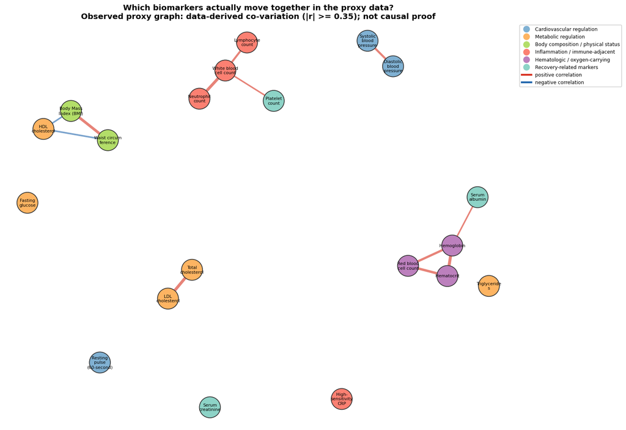

```
Edges drawn (|correlation| >= 0.35): 12
```

```python
# --- Build the observed coherence graph from real correlations -----------
CORR_THRESHOLD = 0.35
corr_feats = [f for f in scored_features]
made_graph = False
if len(corr_feats) >= 3 and len(reference_pool) > MIN_REF_N:
    corr = reference_pool[corr_feats].corr()
    Gc = nx.Graph()
    for f in corr_feats:
        Gc.add_node(f, domain=VARIABLE_REGISTRY.get(f, ("", "Other"))[1])
    edge_weights = []
    for i, a in enumerate(corr_feats):
        for b in corr_feats[i + 1:]:
            r = corr.loc[a, b]
            if pd.notna(r) and abs(r) >= CORR_THRESHOLD:
                Gc.add_edge(a, b, weight=abs(r), sign=np.sign(r))
                edge_weights.append((a, b, r))

    domain_palette = {
        "Cardiovascular regulation": "#80b1d3", "Metabolic regulation": "#fdb462",
        "Body composition / physical status": "#b3de69", "Inflammation / immune-adjacent": "#fb8072",
        "Hematologic / oxygen-carrying": "#bc80bd", "Recovery-related markers": "#8dd3c7",
    }
    fig, ax = plt.subplots(figsize=(15, 12))
    posc = nx.spring_layout(Gc, seed=RANDOM_SEED, k=2.6, iterations=400, scale=2.4)
    node_colors = [domain_palette.get(VARIABLE_REGISTRY.get(n, ("", "Other"))[1], "#cccccc")
                   for n in Gc.nodes()]
    for a, b, r in edge_weights:
        ax.plot([posc[a][0], posc[b][0]], [posc[a][1], posc[b][1]],
                color="#d7301f" if r > 0 else "#2166ac",
                linewidth=1 + 4 * abs(r), alpha=0.6, zorder=1)
    nx.draw_networkx_nodes(Gc, posc, ax=ax, node_color=node_colors, node_size=1200,
                           edgecolors="#333333", linewidths=1.2)
    nx.draw_networkx_labels(Gc, posc, ax=ax, font_size=7,
                            labels={n: "\n".join(textwrap.wrap(VARIABLE_REGISTRY.get(n, (n,))[0], 12))
                                    for n in Gc.nodes()})
    handles = [plt.Line2D([0], [0], marker="o", color="w", markerfacecolor=c, markersize=12, label=d)
               for d, c in domain_palette.items()]
    handles += [plt.Line2D([0], [0], color="#d7301f", lw=3, label="positive correlation"),
                plt.Line2D([0], [0], color="#2166ac", lw=3, label="negative correlation")]
    ax.legend(handles=handles, fontsize=8, loc="upper left", bbox_to_anchor=(1.01, 1.0), framealpha=0.95)
    ax.set_title(f"Which biomarkers actually move together in the proxy data?\nObserved proxy graph: data-derived co-variation (|r| >= {CORR_THRESHOLD}); not causal proof")
    ax.axis("off")
    save_figure(fig, "observed_proxy_coherence_graph.png")
    plt.show()
    made_graph = True
    print(f"Edges drawn (|correlation| >= {CORR_THRESHOLD}): {len(edge_weights)}")
if not made_graph:
    print("Not enough scored features / reference data to build the observed coherence graph.")
```

**Reviewer note:**

- **What it shows:** real co-variation in the proxy reference space - red links rise/fall together, blue links move oppositely; thicker = stronger.
- **Why it matters for HRP:** it separates "what the literature expects" (Section 12) from "what this real dataset actually shows."
- **Takeaway:** clusters tend to form along biological-domain lines, which supports grouping variables into domains - but this is **co-variation, not causation**.

# 14. Decision / Management Graph

**This is graph type 3 of 3: a decision-support graph.** It translates biological **patterns** into HRP-relevant **monitoring priorities, follow-up data streams, and countermeasure considerations**. It contains **no treatment language** - it answers "what should HRP look at and consider monitoring next?", not "what should be prescribed?"

*Technical cell: builds the decision/management graph with networkx.*

```
  [saved figure] results/figures/decision_management_graph.png
```

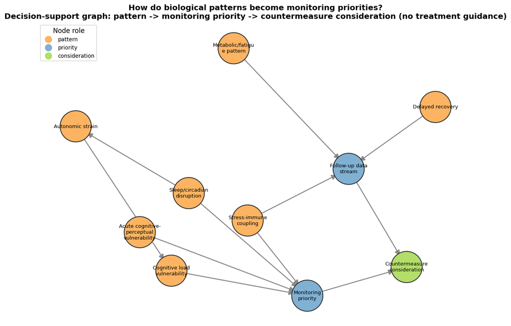

```python
# --- Build and draw the decision / management graph ----------------------
DECISION_NODES = {
    "Sleep/circadian disruption": "pattern",
    "Autonomic strain": "pattern",
    "Stress-immune coupling": "pattern",
    "Metabolic/fatigue pattern": "pattern",
    "Cognitive load vulnerability": "pattern",
    "Acute cognitive-perceptual vulnerability": "pattern",
    "Delayed recovery": "pattern",
    "Monitoring priority": "priority",
    "Follow-up data stream": "priority",
    "Countermeasure consideration": "consideration",
}
DECISION_EDGES = [
    ("Sleep/circadian disruption", "Autonomic strain"),
    ("Sleep/circadian disruption", "Monitoring priority"),
    ("Autonomic strain", "Cognitive load vulnerability"),
    ("Stress-immune coupling", "Monitoring priority"),
    ("Stress-immune coupling", "Follow-up data stream"),
    ("Metabolic/fatigue pattern", "Follow-up data stream"),
    ("Cognitive load vulnerability", "Monitoring priority"),
    ("Acute cognitive-perceptual vulnerability", "Monitoring priority"),
    ("Delayed recovery", "Follow-up data stream"),
    ("Monitoring priority", "Countermeasure consideration"),
    ("Follow-up data stream", "Countermeasure consideration"),
]
DECISION_COLORS = {"pattern": "#fdb462", "priority": "#80b1d3", "consideration": "#b3de69"}

Gd = nx.DiGraph()
for node, role in DECISION_NODES.items():
    Gd.add_node(node, role=role)
Gd.add_edges_from(DECISION_EDGES)

fig, ax = plt.subplots(figsize=(13, 9))
posd = nx.spring_layout(Gd, seed=RANDOM_SEED, k=1.2, iterations=250)
node_colors = [DECISION_COLORS[DECISION_NODES[n]] for n in Gd.nodes()]
nx.draw_networkx_edges(Gd, posd, ax=ax, edge_color="#888888", width=1.6,
                       arrowstyle="-|>", arrowsize=18, min_target_margin=22)
nx.draw_networkx_nodes(Gd, posd, ax=ax, node_color=node_colors, node_size=2700,
                       edgecolors="#333333", linewidths=1.4)
nx.draw_networkx_labels(Gd, posd, ax=ax, font_size=8.5,
                        labels={n: "\n".join(textwrap.wrap(n, 16)) for n in Gd.nodes()})
handles = [plt.Line2D([0], [0], marker="o", color="w", markerfacecolor=c, markersize=13, label=role)
           for role, c in DECISION_COLORS.items()]
ax.legend(handles=handles, title="Node role", loc="upper left", fontsize=9)
ax.set_title("How do biological patterns become monitoring priorities?\nDecision-support graph: pattern -> monitoring priority -> countermeasure consideration (no treatment guidance)")
ax.axis("off")
save_figure(fig, "decision_management_graph.png")
plt.show()
```

**Reviewer note:**

- **What it shows:** the flow from detected biological patterns to **monitoring priorities, follow-up data streams, and countermeasure considerations**.
- **Why it matters for HRP:** this is where analysis becomes **decision-support** that a human-research team can act on.
- **Takeaway:** every endpoint is a *consideration to monitor*, never a treatment - the guardrails hold here too.

# 15. Individual Adaptation Networks

A crew-level average can hide what matters most: **individual** patterns. NeuroBridge-S4 draws an **individual adaptation network** for each pseudo-crew member, so each person can be understood as a distinct biological system. Node size and color reflect how strained each domain is; edges are the known biological relationships between domains. One figure is saved per participant, plus a combined panel.

*Technical cell: per-member adaptation networks and a combined 2x2 panel.*

```
  [saved figure] results/figures/individual_adaptation_network_97774.png
```

```
  [saved figure] results/figures/individual_adaptation_network_94465.png
```

```
  [saved figure] results/figures/individual_adaptation_network_99813.png
  [saved figure] results/figures/individual_adaptation_network_100987.png
```

```
  [saved figure] results/figures/individual_adaptation_networks_panel.png
```

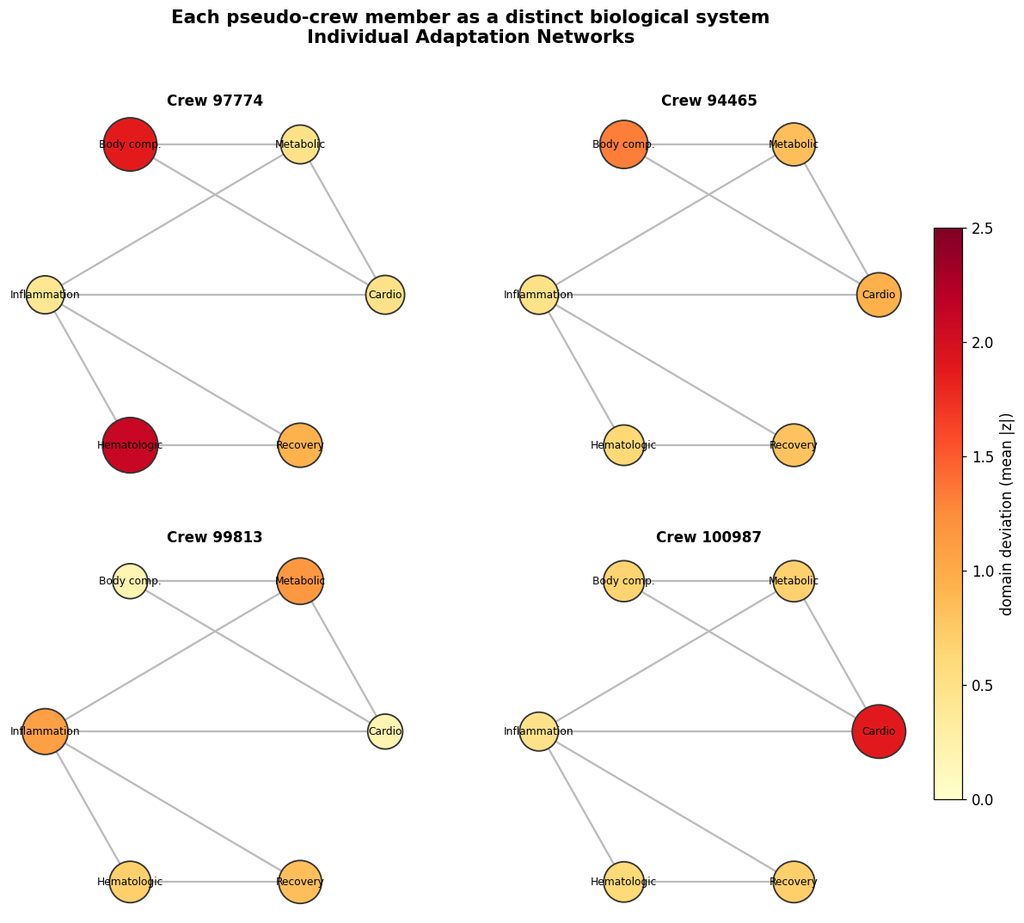

```python
# --- Known relationships between biological domains ----------------------
DOMAIN_EDGES = [
    ("Cardiovascular regulation", "Inflammation / immune-adjacent"),
    ("Cardiovascular regulation", "Metabolic regulation"),
    ("Metabolic regulation", "Inflammation / immune-adjacent"),
    ("Metabolic regulation", "Body composition / physical status"),
    ("Inflammation / immune-adjacent", "Hematologic / oxygen-carrying"),
    ("Inflammation / immune-adjacent", "Recovery-related markers"),
    ("Hematologic / oxygen-carrying", "Recovery-related markers"),
    ("Body composition / physical status", "Cardiovascular regulation"),
]

SHORT_DOMAIN = {
    "Cardiovascular regulation": "Cardio",
    "Metabolic regulation": "Metabolic",
    "Body composition / physical status": "Body comp.",
    "Inflammation / immune-adjacent": "Inflammation",
    "Hematologic / oxygen-carrying": "Hematologic",
    "Recovery-related markers": "Recovery",
}


def draw_individual_network(ax, member_label, domain_row):
    Gi = nx.Graph()
    domains = list(domain_scores.columns)
    for d in domains:
        Gi.add_node(d)
    for a, b in DOMAIN_EDGES:
        if a in domains and b in domains:
            Gi.add_edge(a, b)
    posi = nx.circular_layout(Gi)
    vals = np.array([domain_row.get(d, np.nan) for d in domains], dtype=float)
    vals = np.nan_to_num(vals, nan=0.0)
    sizes = 600 + 1400 * np.clip(vals / 2.5, 0, 1)
    nx.draw_networkx_edges(Gi, posi, ax=ax, edge_color="#bbbbbb", width=1.5)
    nodes = nx.draw_networkx_nodes(Gi, posi, ax=ax, node_color=vals, cmap="YlOrRd",
                                   vmin=0, vmax=2.5, node_size=sizes,
                                   edgecolors="#333333", linewidths=1.2)
    nx.draw_networkx_labels(Gi, posi, ax=ax, font_size=8,
                            labels={d: SHORT_DOMAIN.get(d, d) for d in domains})
    ax.set_title(member_label, fontsize=11)
    ax.axis("off")
    return nodes


for member_label, domain_row in domain_scores.iterrows():
    seqn = int(member_label.split()[1])
    fig, ax = plt.subplots(figsize=(6.5, 6))
    nodes = draw_individual_network(ax, member_label, domain_row)
    cb = fig.colorbar(nodes, ax=ax, fraction=0.046, pad=0.04)
    cb.set_label("domain deviation (mean |z|)")
    fig.suptitle(f"Individual Adaptation Network - {member_label}", fontsize=12, fontweight="bold")
    save_figure(fig, f"individual_adaptation_network_{seqn}.png")
    plt.close(fig)

if not domain_scores.empty:
    n_members = len(domain_scores)
    fig, axes = plt.subplots(2, 2, figsize=(13, 11))
    axes = axes.flatten()
    last_nodes = None
    for i, (member_label, domain_row) in enumerate(domain_scores.iterrows()):
        last_nodes = draw_individual_network(axes[i], member_label, domain_row)
    for j in range(n_members, len(axes)):
        axes[j].axis("off")
    fig.suptitle("Each pseudo-crew member as a distinct biological system\nIndividual Adaptation Networks",
                 fontsize=14, fontweight="bold")
    if last_nodes is not None:
        cb = fig.colorbar(last_nodes, ax=axes.tolist(), fraction=0.03, pad=0.02)
        cb.set_label("domain deviation (mean |z|)")
    save_figure(fig, "individual_adaptation_networks_panel.png")
    plt.show()
```

**Reviewer note:**

- **What it shows:** four separate "system maps," one per member; larger/darker nodes = more strained domains.
- **Why it matters for HRP:** even within the same four-person group, adaptation patterns differ - some concentrated, some broad.
- **Takeaway:** this is the core of NeuroBridge-S4 - **individualized** interpretation rather than a single crew average.

# 16. Countermeasure Priority Map

This map links **detected patterns** to **operational support categories**. It is **decision-support, not medical advice**: we use the language of *monitoring priority*, *follow-up data stream*, and *countermeasure consideration* - never treatment or diagnosis.

*Technical cell: conceptual mapping of pattern -> support category, rendered as a matrix.*

```
  [saved figure] results/figures/countermeasure_priority_map.png
```

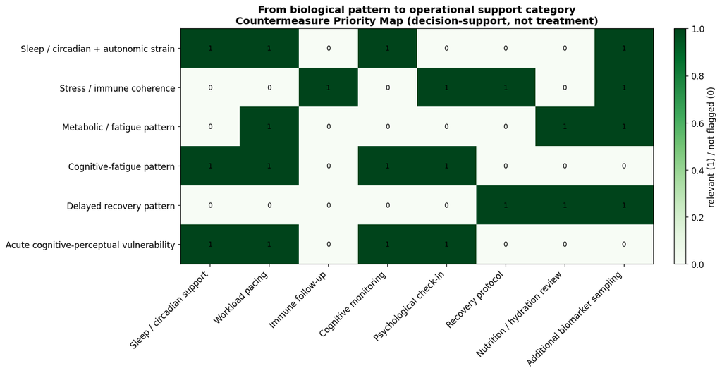

```python
# --- Conceptual mapping: detected pattern -> management priority ---------
PATTERNS = [
    "Sleep / circadian + autonomic strain",
    "Stress / immune coherence",
    "Metabolic / fatigue pattern",
    "Cognitive-fatigue pattern",
    "Delayed recovery pattern",
    "Acute cognitive-perceptual vulnerability",
]
PRIORITIES = [
    "Sleep / circadian support", "Workload pacing", "Immune follow-up", "Cognitive monitoring",
    "Psychological check-in", "Recovery protocol", "Nutrition / hydration review",
    "Additional biomarker sampling",
]
PRIORITY_MAP = {
    "Sleep / circadian + autonomic strain":
        ["Sleep / circadian support", "Workload pacing", "Cognitive monitoring", "Additional biomarker sampling"],
    "Stress / immune coherence":
        ["Immune follow-up", "Psychological check-in", "Recovery protocol", "Additional biomarker sampling"],
    "Metabolic / fatigue pattern":
        ["Nutrition / hydration review", "Workload pacing", "Additional biomarker sampling"],
    "Cognitive-fatigue pattern":
        ["Cognitive monitoring", "Workload pacing", "Sleep / circadian support", "Psychological check-in"],
    "Delayed recovery pattern":
        ["Recovery protocol", "Additional biomarker sampling", "Nutrition / hydration review"],
    "Acute cognitive-perceptual vulnerability":
        ["Psychological check-in", "Cognitive monitoring", "Sleep / circadian support", "Workload pacing"],
}

priority_matrix = np.zeros((len(PATTERNS), len(PRIORITIES)))
for i, pat in enumerate(PATTERNS):
    for pr in PRIORITY_MAP[pat]:
        priority_matrix[i, PRIORITIES.index(pr)] = 1.0

fig, ax = plt.subplots(figsize=(12, 5.5))
annotated_heatmap(ax, priority_matrix, PATTERNS, PRIORITIES, cmap="Greens",
                  vmin=0, vmax=1, fmt="{:.0f}", cbar_label="relevant (1) / not flagged (0)")
ax.set_title("From biological pattern to operational support category\nCountermeasure Priority Map (decision-support, not treatment)")
save_figure(fig, "countermeasure_priority_map.png")
plt.show()
```

**Reviewer note:**

- **What it shows:** which monitoring/support categories each coherent pattern points toward.
- **Why it matters for HRP:** it turns "this system is strained" into "here is what could be monitored or considered."
- **Takeaway:** every entry is a **consideration**, framed for HRP judgment - never a prescription.

# 17. What Each NeuroBridge-S4 Layer Adds

NeuroBridge-S4 is a stack of layers, each adding interpretive value. The table below makes that value explicit: raw variables are hard to read; each subsequent layer adds structure until the output is an actionable monitoring priority.

*Technical cell: builds the layer-value table and figure.*

```
What each NeuroBridge-S4 layer adds:
```

|  | Layer | Output | Value added for HRP |
| --- | --- | --- | --- |
| 0 | Raw variables | Dozens of mixed-unit measurements | Hard to interpret; no comparison or structure |
| 1 | Reference deviation scores | Per-feature z-scores | Shows how unusual each value is vs the referen... |
| 2 | Biological domain compression | Mean \|z\| per system | Shows which biological systems are affected |
| 3 | BACI coherence | 0-100 triage score | Shows whether systems shift together (signal v... |
| 4 | Biological knowledge graph | Conceptual system map | Explains why coordinated shifts are biological... |
| 5 | Observed proxy graph | Data-derived co-variation | Shows real relationships in the proxy referenc... |
| 6 | Decision / management graph | Pattern -> priority map | Translates patterns into monitoring priorities |
| 7 | Individual adaptation profile | Per-member report | Human-readable, individualized interpretation |
| 8 | Crew-level summary | Crew-at-a-glance table | Preserves individual differences for the whole... |

```
  [saved figure] results/figures/layer_value_analysis.png
```

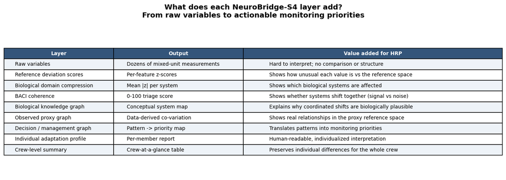

```python
# --- Layer value (ablation-style) analysis -------------------------------
layer_rows = [
    ("Raw variables", "Dozens of mixed-unit measurements", "Hard to interpret; no comparison or structure"),
    ("Reference deviation scores", "Per-feature z-scores", "Shows how unusual each value is vs the reference space"),
    ("Biological domain compression", "Mean |z| per system", "Shows which biological systems are affected"),
    ("BACI coherence", "0-100 triage score", "Shows whether systems shift together (signal vs noise)"),
    ("Biological knowledge graph", "Conceptual system map", "Explains why coordinated shifts are biologically plausible"),
    ("Observed proxy graph", "Data-derived co-variation", "Shows real relationships in the proxy reference space"),
    ("Decision / management graph", "Pattern -> priority map", "Translates patterns into monitoring priorities"),
    ("Individual adaptation profile", "Per-member report", "Human-readable, individualized interpretation"),
    ("Crew-level summary", "Crew-at-a-glance table", "Preserves individual differences for the whole crew"),
]
layer_value = pd.DataFrame(layer_rows, columns=["Layer", "Output", "Value added for HRP"])
layer_value.to_csv(RESULTS / "layer_value_analysis.csv", index=False)
print("What each NeuroBridge-S4 layer adds:")
display(layer_value)

fig, ax = plt.subplots(figsize=(16, 4.8))
ax.axis("off")
tbl = ax.table(cellText=layer_value.values, colLabels=layer_value.columns,
               cellLoc="left", loc="center", colWidths=[0.22, 0.26, 0.52])
tbl.auto_set_font_size(False)
tbl.set_fontsize(9)
tbl.scale(1, 1.6)
for j in range(layer_value.shape[1]):
    tbl[0, j].set_facecolor("#34557a")
    tbl[0, j].set_text_props(color="white", fontweight="bold")
for i in range(1, layer_value.shape[0] + 1):
    shade = "#eef3f8" if i % 2 else "#ffffff"
    for j in range(layer_value.shape[1]):
        tbl[i, j].set_facecolor(shade)
ax.set_title("What does each NeuroBridge-S4 layer add?\nFrom raw variables to actionable monitoring priorities", pad=18)
save_figure(fig, "layer_value_analysis.png")
plt.show()
```

**Reviewer note:**

- **What it shows:** the incremental value of each analytic layer, from raw numbers to monitoring priorities.
- **Why it matters for HRP:** it demonstrates that no single layer is "magic" - value accumulates transparently.
- **Takeaway:** the method's strength is the **disciplined assembly** of interpretable layers, not any one black box.

# 18. Individual Adaptation Profile Reports

The final per-member output is a **human-readable report**, not just a chart. Each report lists the top deviating features, the most affected biological domains, the BACI score/category and its sensitivity note, a short network interpretation, and **monitoring priorities, follow-up data streams, and countermeasure considerations** - all framed as decision-support. **No diagnosis, no treatment.** Reports are saved to `results/adaptation_profiles.txt`.

*Technical cell: generates one adaptation profile report per pseudo-crew member.*

```python
# --- Generate one adaptation profile report per pseudo-crew member -------
DOMAIN_FOLLOWUP = {
    "Cardiovascular regulation": "HRV / autonomic monitoring; resting HR and blood-pressure tracking",
    "Metabolic regulation": "fasting glucose and lipid re-check; nutrition / metabolic follow-up",
    "Body composition / physical status": "body-composition tracking; physical conditioning load review",
    "Inflammation / immune-adjacent": "immune biomarker follow-up (CRP, white-cell differential); stress-immune panel",
    "Hematologic / oxygen-carrying": "hemoglobin / hematocrit follow-up; oxygen-carrying capacity",
    "Recovery-related markers": "albumin / creatinine recovery markers; recovery-trajectory tracking",
}
DOMAIN_PATTERN = {
    "Cardiovascular regulation": "Autonomic / cardiovascular strain",
    "Metabolic regulation": "Metabolic / fatigue pattern",
    "Body composition / physical status": "Physical-status shift",
    "Inflammation / immune-adjacent": "Stress-immune coupling",
    "Hematologic / oxygen-carrying": "Oxygen-carrying shift",
    "Recovery-related markers": "Delayed recovery pattern",
}
DOMAIN_COUNTERMEASURE = {
    "Cardiovascular regulation": "autonomic/cardiovascular monitoring consideration",
    "Metabolic regulation": "nutrition / metabolic review consideration",
    "Body composition / physical status": "physical-conditioning load consideration",
    "Inflammation / immune-adjacent": "immune follow-up and recovery-tracking consideration",
    "Hematologic / oxygen-carrying": "oxygen-carrying capacity monitoring consideration",
    "Recovery-related markers": "recovery-protocol and hydration/nutrition consideration",
}
BACI_INTERPRETATION = {
    "low coherence": "Deviations look isolated; no coordinated multi-system adaptation signal at this time.",
    "mild coherence": "A modest, partly coordinated signal; routine monitoring is reasonable.",
    "moderate coherence": "Several systems shift together; this warrants prioritized monitoring.",
    "high coherence": "A strongly coordinated multi-system signal; highest monitoring priority among the crew.",
}


def build_report(member_label):
    seqn = int(member_label.split()[1])
    lines = []
    add = lines.append
    add("=" * 74)
    add("NeuroBridge-S4  |  Individual Adaptation Profile")
    add(f"Pseudo-crew participant (anonymized NHANES SEQN): {seqn}")
    add("Data source: real NHANES 2017-2018 public data (NOT Artemis II astronaut data)")
    add("=" * 74)

    z_row = deviation_scores.loc[member_label].dropna()
    top_feats = z_row.abs().sort_values(ascending=False).head(5)
    add("")
    add("Top deviating features (vs health-filtered reference cohort):")
    for label, _ in top_feats.items():
        add(f"   - {label:38s} reference deviation z = {z_row[label]:+.2f}")

    dom_row = domain_scores.loc[member_label].dropna().sort_values(ascending=False)
    add("")
    add("Top affected biological domains:")
    for d, v in dom_row.head(3).items():
        add(f"   - {d:42s} mean |z| = {v:.2f}")

    score = baci_scores.loc[member_label, "BACI"]
    cat = baci_scores.loc[member_label, "category"]
    add("")
    add(f"BACI score (signal-triage, not a diagnosis): {score:.0f} / 100  ({cat})")
    add(f"   {BACI_INTERPRETATION[cat]}")
    add(f"   BACI sensitivity: crew ranking across thresholds 0.75/1.00/1.25 was "
        f"{'stable' if ranking_stable else 'threshold-sensitive (review borderline members)'}.")

    add("")
    add("Network / graph interpretation summary:")
    if len(dom_row):
        top_d = dom_row.index[0]
        connected = [b if a == top_d else a for a, b in DOMAIN_EDGES if top_d in (a, b)]
        add(f"   - Primary cluster: {top_d}")
        if connected:
            add(f"   - Biologically linked systems to watch alongside it: {', '.join(connected)}")
        add(f"   - Pattern label: {DOMAIN_PATTERN.get(top_d, 'mixed pattern')}")

    add("")
    add("Monitoring priorities (decision-support, not treatment):")
    for d, _ in dom_row.head(3).items():
        add(f"   - {DOMAIN_FOLLOWUP.get(d, 'targeted follow-up sampling')}")

    add("")
    add("Follow-up data streams to prioritize:")
    for s in ["sleep / circadian monitoring", "HRV / autonomic monitoring", "immune biomarker follow-up",
              "metabolic follow-up", "cognitive performance monitoring", "validated psychological self-report",
              "recovery-trajectory tracking"]:
        add(f"   - {s}")

    add("")
    add("Countermeasure considerations (categories only, not prescriptions):")
    for d, _ in dom_row.head(2).items():
        add(f"   - {DOMAIN_COUNTERMEASURE.get(d, 'targeted monitoring consideration')}")

    add("")
    add("Note: This is decision-support only. No medical diagnosis. No treatment recommendation.")
    add("")
    return "\n".join(lines)


reports = [build_report(label) for label in domain_scores.index]
full_report_text = "\n".join(reports)
report_path = RESULTS / "adaptation_profiles.txt"
report_path.write_text(full_report_text)
print(f"Wrote {len(reports)} adaptation profiles -> {report_path}\n")
print(reports[0] if reports else "No reports generated (structure-only fallback).")
```

```
Wrote 4 adaptation profiles -> results/adaptation_profiles.txt

==========================================================================
NeuroBridge-S4  |  Individual Adaptation Profile
Pseudo-crew participant (anonymized NHANES SEQN): 97774
Data source: real NHANES 2017-2018 public data (NOT Artemis II astronaut data)
==========================================================================

Top deviating features (vs health-filtered reference cohort):
   - Hematocrit                             reference deviation z = +2.24
   - Hemoglobin                             reference deviation z = +2.14
   - Red blood cell count                   reference deviation z = +1.94
   - Serum albumin                          reference deviation z = +1.87
   - Body Mass Index (BMI)                  reference deviation z = -1.87

Top affected biological domains:
   - Hematologic / oxygen-carrying              mean |z| = 2.11
   - Body composition / physical status         mean |z| = 1.87
   - Recovery-related markers                   mean |z| = 0.94

BACI score (signal-triage, not a diagnosis): 42 / 100  (mild coherence)
   A modest, partly coordinated signal; routine monitoring is reasonable.
   BACI sensitivity: crew ranking across thresholds 0.75/1.00/1.25 was threshold-sensitive (review borderline members).

Network / graph interpretation summary:
   - Primary cluster: Hematologic / oxygen-carrying
   - Biologically linked systems to watch alongside it: Inflammation / immune-adjacent, Recovery-related markers
   - Pattern label: Oxygen-carrying shift

Monitoring priorities (decision-support, not treatment):
   - hemoglobin / hematocrit follow-up; oxygen-carrying capacity
   - body-composition tracking; physical conditioning load review
   - albumin / creatinine recovery markers; recovery-trajectory tracking

Follow-up data streams to prioritize:
   - sleep / circadian monitoring
   - HRV / autonomic monitoring
   - immune biomarker follow-up
   - metabolic follow-up
   - cognitive performance monitoring
   - validated psychological self-report
   - recovery-trajectory tracking

Countermeasure considerations (categories only, not prescriptions):
   - oxygen-carrying capacity monitoring consideration
   - physical-conditioning load consideration

Note: This is decision-support only. No medical diagnosis. No treatment recommendation.
```

**Reviewer note:**

- **What it shows:** a short, structured briefing per member - what stands out, which systems, how coherent, and what to monitor next.
- **Why it matters for HRP:** this is the deliverable a human-research team can actually read and act on.
- **Takeaway:** every report ends with the explicit **no-diagnosis / no-treatment** guardrail.

# 19. Artemis II Translation Map

NeuroBridge-S4 is designed specifically for the **three Artemis II human research study streams**, not as a generic wellness model. Each stream maps to a NeuroBridge-S4 layer with clear HRP value:

| Artemis II stream | Data type | NeuroBridge-S4 layer | HRP value |
| --- | --- | --- | --- |
| **Standard Measures** | Biomarkers, physiological/functional state | Reference deviation + biological domains | Which systems deviate, and how unusually |
| **ARCHeR** | Sleep, activity, well-being, social interaction | Behavioral signals -> autonomic/cognitive interpretation | Sleep/circadian and workload context |
| **Immune Biomarkers** | Stress-immune markers | Inflammation/immune domain + stress-immune coherence | Stress-immune coupling and follow-up priorities |

**Important scope note.** In actual Artemis II use, NHANES would **not** be the main target - it would be **one lower-level reference layer**. The real value would come from combining: an **individual pre-mission baseline**, **in-mission measurements**, **post-mission recovery data**, **actigraphy/sleep**, **immune/stress biomarkers**, **cognitive performance**, and **validated psychological self-report**.

*Technical cell: builds the Artemis II translation flow diagram.*

```
  [saved figure] results/figures/artemis_translation_map.png
```

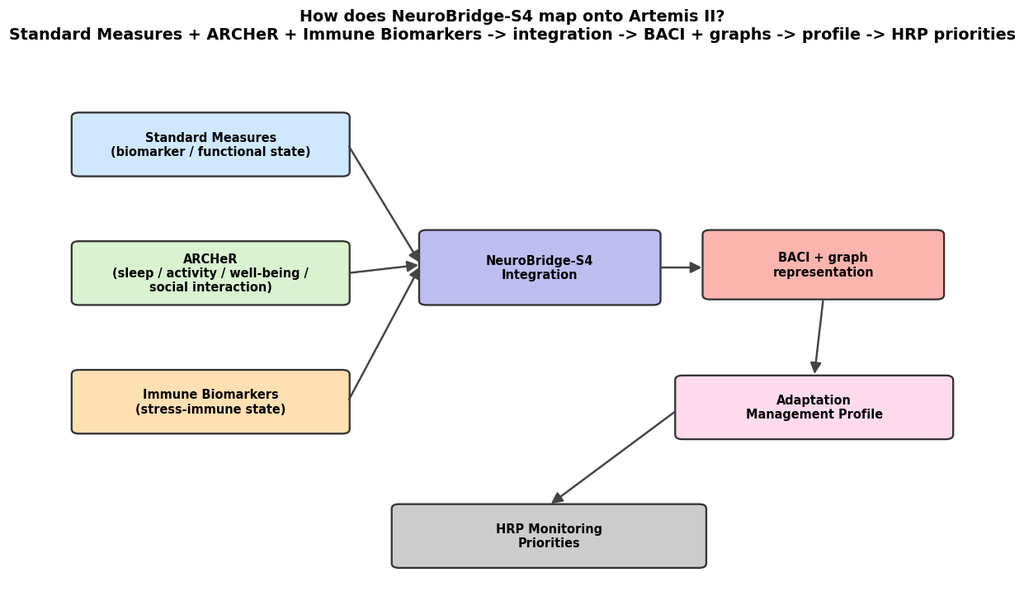

```python
# --- Figure: Artemis II translation flow diagram -------------------------
fig, ax = plt.subplots(figsize=(13, 8))
ax.set_xlim(0, 10)
ax.set_ylim(0, 10)
ax.axis("off")


def flow_box(x, y, w, h, text, color):
    box = FancyBboxPatch((x, y), w, h, boxstyle="round,pad=0.02,rounding_size=0.08",
                         linewidth=1.5, edgecolor="#333333", facecolor=color)
    ax.add_patch(box)
    ax.text(x + w / 2, y + h / 2, text, ha="center", va="center", fontsize=9.5, fontweight="bold")


def arrow(x1, y1, x2, y2):
    ax.add_patch(FancyArrowPatch((x1, y1), (x2, y2), arrowstyle="-|>", mutation_scale=18,
                                 linewidth=1.6, color="#444444"))


flow_box(0.2, 7.7, 3.0, 1.1, "Standard Measures\n(biomarker / functional state)", "#cfe8ff")
flow_box(0.2, 5.4, 3.0, 1.1, "ARCHeR\n(sleep / activity / well-being /\nsocial interaction)", "#d9f2d0")
flow_box(0.2, 3.1, 3.0, 1.1, "Immune Biomarkers\n(stress-immune state)", "#ffe0b3")

flow_box(4.0, 5.4, 2.6, 1.3, "NeuroBridge-S4\nIntegration", "#bdbdf0")
flow_box(7.1, 5.5, 2.6, 1.2, "BACI + graph\nrepresentation", "#fbb4ae")
flow_box(6.8, 3.0, 3.0, 1.1, "Adaptation\nManagement Profile", "#fddaec")
flow_box(3.7, 0.7, 3.4, 1.1, "HRP Monitoring\nPriorities", "#cccccc")

for sy in (8.25, 5.95, 3.65):
    arrow(3.2, sy, 4.0, 6.1)
arrow(6.6, 6.05, 7.1, 6.05)
arrow(8.4, 5.5, 8.3, 4.1)
arrow(6.8, 3.5, 5.4, 1.8)

ax.set_title("How does NeuroBridge-S4 map onto Artemis II?\nStandard Measures + ARCHeR + Immune Biomarkers -> integration -> BACI + graphs -> profile -> HRP priorities",
             fontsize=12.5)
save_figure(fig, "artemis_translation_map.png")
plt.show()
```

**Reviewer note:**

- **What it shows:** each official Artemis II data stream has a defined entry point into NeuroBridge-S4.
- **Why it matters for HRP:** the method is **purpose-built** for Standard Measures, ARCHeR, and Immune Biomarkers - not a generic model.
- **Takeaway:** NHANES is only a reference rung here; real value comes from longitudinal Artemis II streams plus each astronaut's own baseline.

# 20. Acute cognitive-perceptual vulnerability layer (conceptual)

**Acute cognitive-perceptual vulnerability is treated as a monitoring context, not a diagnosis.** States such as derealization-like detachment, sensory unreality, or emotional numbing **should not** be inferred from biomarkers, and this framework does **not** attempt to detect or diagnose them.

Instead, NeuroBridge-S4 can **flag convergence** among **sleep disruption, autonomic strain, stress biology, immune/inflammatory shift, cognitive fatigue, and validated self-report** as a reason to **prioritize cognitive and psychological monitoring** - especially under the combined pressure of mission stress and isolation. The terms used are deliberately careful: *acute cognitive-perceptual vulnerability*, *cognitive-perceptual strain*, *emotional regulation load*, *evidence-based psychological indicators*, *validated self-report*, and *monitoring priority*.

*Technical cell: conceptual vulnerability graph (a monitoring flag, not a diagnosis).*

```
  [saved figure] results/figures/acute_cognitive_perceptual_layer.png
```

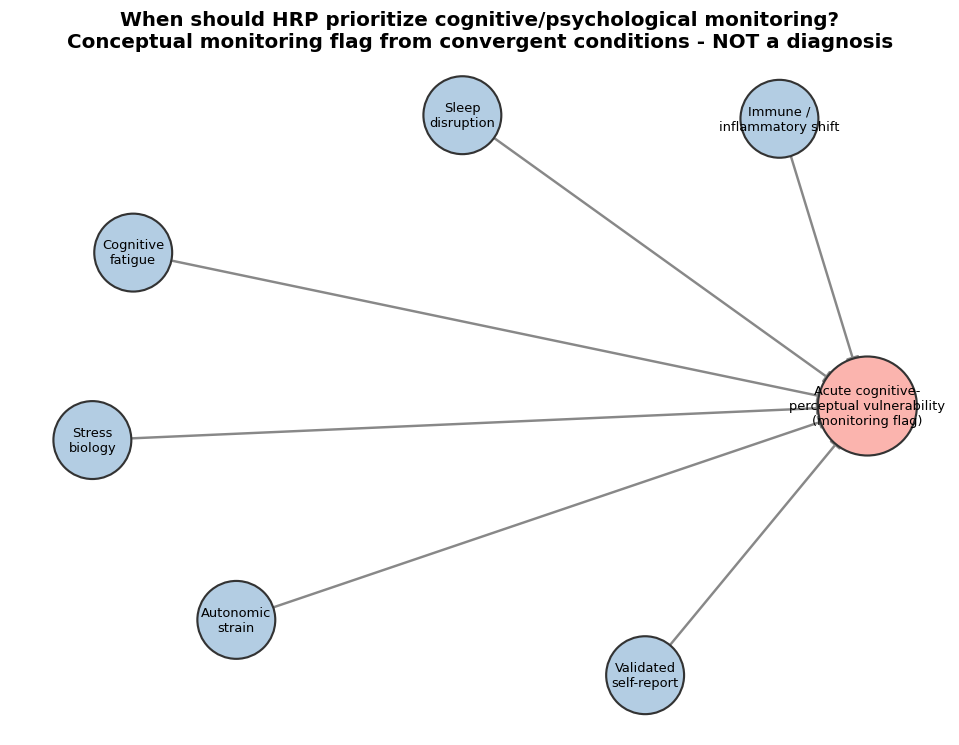

```python
# --- Figure: acute cognitive-perceptual vulnerability layer --------------
Ga = nx.DiGraph()
contributors = [
    "Sleep\ndisruption", "Autonomic\nstrain", "Stress\nbiology",
    "Immune /\ninflammatory shift", "Cognitive\nfatigue", "Validated\nself-report",
]
center = "Acute cognitive-\nperceptual vulnerability\n(monitoring flag)"
for c in contributors:
    Ga.add_edge(c, center)

fig, ax = plt.subplots(figsize=(11, 8))
posa = nx.spring_layout(Ga, seed=RANDOM_SEED, k=1.4, iterations=250)
node_colors = ["#fbb4ae" if n == center else "#b3cde3" for n in Ga.nodes()]
node_sizes = [4200 if n == center else 2600 for n in Ga.nodes()]
nx.draw_networkx_edges(Ga, posa, ax=ax, edge_color="#888888", width=1.6,
                       arrowstyle="-|>", arrowsize=18, min_target_margin=24)
nx.draw_networkx_nodes(Ga, posa, ax=ax, node_color=node_colors, node_size=node_sizes,
                       edgecolors="#333333", linewidths=1.4)
nx.draw_networkx_labels(Ga, posa, ax=ax, font_size=8.5)
ax.set_title("When should HRP prioritize cognitive/psychological monitoring?\nConceptual monitoring flag from convergent conditions - NOT a diagnosis")
ax.axis("off")
save_figure(fig, "acute_cognitive_perceptual_layer.png")
plt.show()
```

**Reviewer note:**

- **What it shows:** the converging conditions that, together, justify raising a **monitoring flag**.
- **Why it matters for HRP:** it provides a careful, evidence-aligned trigger to increase cognitive/psychological monitoring before strain escalates.
- **Takeaway:** this is a **monitoring context, not a diagnosis** - no subjective state is inferred from biomarkers.

# 21. Crew-Level Summary

For Artemis II, a crew-level summary must **not** average away individual differences. Instead it surfaces each member's top system, coherence, primary pattern, and the monitoring priority and follow-up data stream that follow.

*Technical cell: builds the crew-level summary table, CSV, and figure.*

```python
# --- Build the crew-level summary table ----------------------------------
DOMAIN_PRIORITY = {
    "Cardiovascular regulation": "Autonomic / cardiovascular monitoring",
    "Metabolic regulation": "Nutrition / metabolic follow-up",
    "Body composition / physical status": "Physical conditioning & body-composition tracking",
    "Inflammation / immune-adjacent": "Immune biomarker follow-up",
    "Hematologic / oxygen-carrying": "Oxygen-carrying capacity monitoring",
    "Recovery-related markers": "Recovery & nutrition tracking",
}

summary_rows = []
for member_label in domain_scores.index:
    dom_row = domain_scores.loc[member_label].dropna()
    top_domain = dom_row.idxmax() if len(dom_row) else "-"
    summary_rows.append({
        "Participant ID": member_label,
        "Top biological domain": top_domain,
        "BACI score": baci_scores.loc[member_label, "BACI"],
        "BACI category": baci_scores.loc[member_label, "category"],
        "Primary pattern / cluster": DOMAIN_PATTERN.get(top_domain, "mixed pattern"),
        "Suggested monitoring priority": DOMAIN_PRIORITY.get(top_domain, "Targeted follow-up sampling"),
        "Recommended follow-up data stream": DOMAIN_FOLLOWUP.get(top_domain, "targeted follow-up sampling"),
    })

crew_level_summary = pd.DataFrame(summary_rows)
print("Crew-level summary:")
display(crew_level_summary)
crew_level_summary.to_csv(RESULTS / "crew_level_summary.csv", index=False)
print(f"\n  [saved] {RESULTS / 'crew_level_summary.csv'}")
```

```
Crew-level summary:
```

|  | Participant ID | Top biological domain | BACI score | BACI category | Primary pattern / cluster | Suggested monitoring priority | Recommended follow-up data stream |
| --- | --- | --- | --- | --- | --- | --- | --- |
| 0 | Crew 97774 | Hematologic / oxygen-carrying | 41.5 | mild coherence | Oxygen-carrying shift | Oxygen-carrying capacity monitoring | hemoglobin / hematocrit follow-up; oxygen-carr... |
| 1 | Crew 94465 | Body composition / physical status | 22.1 | low coherence | Physical-status shift | Physical conditioning & body-composition tracking | body-composition tracking; physical conditioni... |
| 2 | Crew 99813 | Metabolic regulation | 31.5 | mild coherence | Metabolic / fatigue pattern | Nutrition / metabolic follow-up | fasting glucose and lipid re-check; nutrition ... |
| 3 | Crew 100987 | Cardiovascular regulation | 28.6 | mild coherence | Autonomic / cardiovascular strain | Autonomic / cardiovascular monitoring | HRV / autonomic monitoring; resting HR and blo... |

```
  [saved] results/crew_level_summary.csv
```

```
  [saved figure] results/figures/crew_level_summary.png
```

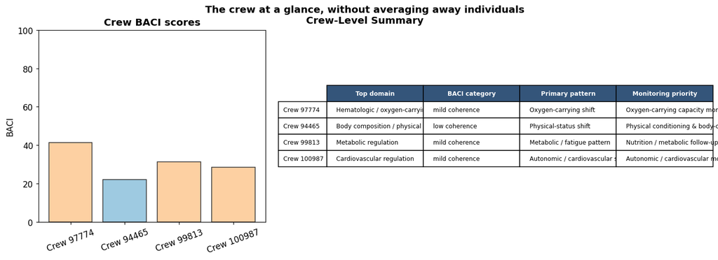

```python
# --- Figure: crew-level summary -----------------------------------------
if not crew_level_summary.empty:
    fig, (ax0, ax1) = plt.subplots(1, 2, figsize=(16, 4.6),
                                   gridspec_kw={"width_ratios": [1, 1.7]})
    colors = [cat_color[c] for c in crew_level_summary["BACI category"]]
    ax0.bar(crew_level_summary["Participant ID"], crew_level_summary["BACI score"],
            color=colors, edgecolor="#333333")
    ax0.set_ylim(0, 100)
    ax0.set_ylabel("BACI")
    ax0.set_title("Crew BACI scores")
    ax0.tick_params(axis="x", rotation=20)

    ax1.axis("off")
    tbl = ax1.table(
        cellText=crew_level_summary[["Top biological domain", "BACI category",
                                     "Primary pattern / cluster", "Suggested monitoring priority"]].values,
        rowLabels=crew_level_summary["Participant ID"].values,
        colLabels=["Top domain", "BACI category", "Primary pattern", "Monitoring priority"],
        cellLoc="left", loc="center")
    tbl.auto_set_font_size(False)
    tbl.set_fontsize(8)
    tbl.scale(1, 1.8)
    for j in range(4):
        tbl[0, j].set_facecolor("#34557a")
        tbl[0, j].set_text_props(color="white", fontweight="bold")
    fig.suptitle("The crew at a glance, without averaging away individuals\nCrew-Level Summary",
                 fontsize=13, fontweight="bold")
    save_figure(fig, "crew_level_summary.png")
    plt.show()
```

**Reviewer note:**

- **What it shows:** every member's top system, coherence, primary pattern, and the monitoring priority + follow-up stream that follow.
- **Why it matters for HRP:** it gives a crew-wide view while preserving the individual detail small-N work depends on.
- **Takeaway:** shared signals and divergent trajectories are visible side by side.

# 22. What HRP could do with this output

These are **illustrative monitoring considerations**, not treatment guidance.

- **If the output shows sleep/circadian + autonomic + fatigue coherence** -> HRP may prioritize sleep/circadian monitoring, HRV/autonomic monitoring, cognitive performance tracking, and workload-pacing consideration.
- **If the output shows stress-immune coherence** -> HRP may prioritize immune biomarker follow-up, stress-load monitoring, and recovery tracking.
- **If the output shows an isolated biomarker deviation** -> HRP may treat it as a **lower-confidence** finding requiring confirmation before action.
- **If the output shows a delayed-recovery pattern** -> HRP may prioritize post-mission recovery follow-up.

In every case, the output answers **"what should HRP look at more closely?"** - never **"what treatment should be given?"**

# 23. Export all outputs

All tables and figures are written under `results/` and `results/figures/` so the demonstration is fully reproducible. The cell below saves every table and prints a final checklist.

*Technical cell: saves all data tables and prints the final file checklist.*

```python
# --- Save all tables and print a final checklist -------------------------
exports = {}

if len(reference_cohort) and ANALYSIS_FEATURES:
    ref_summary = reference_cohort[[f for f in ANALYSIS_FEATURES if f in reference_cohort.columns]].describe().T
    ref_summary.index = [VARIABLE_REGISTRY.get(i, (i,))[0] for i in ref_summary.index]
    ref_summary.to_csv(RESULTS / "reference_cohort_summary.csv")
    exports["reference_cohort_summary.csv"] = True

if len(pseudo_crew):
    pseudo_crew[crew_display_cols].to_csv(RESULTS / "pseudo_crew.csv", index=False)
    exports["pseudo_crew.csv"] = True

if not deviation_scores.empty:
    deviation_scores.to_csv(RESULTS / "deviation_scores.csv")
    exports["deviation_scores.csv"] = True

if not domain_scores.empty:
    domain_scores.to_csv(RESULTS / "domain_scores.csv")
    exports["domain_scores.csv"] = True

if not baci_scores.empty:
    baci_scores.to_csv(RESULTS / "baci_scores.csv")
    exports["baci_scores.csv"] = True

exports["baci_sensitivity.csv"] = (RESULTS / "baci_sensitivity.csv").exists()
exports["layer_value_analysis.csv"] = (RESULTS / "layer_value_analysis.csv").exists()

if not crew_level_summary.empty:
    crew_level_summary.to_csv(RESULTS / "crew_level_summary.csv", index=False)
    exports["crew_level_summary.csv"] = True

exports["adaptation_profiles.txt"] = (RESULTS / "adaptation_profiles.txt").exists()

print("=" * 60)
print("FINAL CHECKLIST OF GENERATED FILES")
print("=" * 60)
print("\nData tables and reports (results/):")
for name, ok in exports.items():
    print(f"   [{'x' if ok else ' '}] {name}")

figure_files = sorted(p.name for p in FIGURES.glob("*.png"))
print(f"\nFigures (results/figures/): {len(figure_files)} saved")
for name in figure_files:
    print(f"   [x] figures/{name}")
```

```
============================================================
FINAL CHECKLIST OF GENERATED FILES
============================================================

Data tables and reports (results/):
   [x] reference_cohort_summary.csv
   [x] pseudo_crew.csv
   [x] deviation_scores.csv
   [x] domain_scores.csv
   [x] baci_scores.csv
   [x] baci_sensitivity.csv
   [x] layer_value_analysis.csv
   [x] crew_level_summary.csv
   [x] adaptation_profiles.txt

Figures (results/figures/): 20 saved
   [x] figures/acute_cognitive_perceptual_layer.png
   [x] figures/artemis_translation_map.png
   [x] figures/baci_scores.png
   [x] figures/baci_sensitivity_analysis.png
   [x] figures/biological_domain_heatmap.png
   [x] figures/biological_knowledge_graph.png
   [x] figures/cohort_filtering_funnel.png
   [x] figures/control_ladder.png
   [x] figures/countermeasure_priority_map.png
   [x] figures/crew_level_summary.png
   [x] figures/decision_management_graph.png
   [x] figures/individual_adaptation_network_100987.png
   [x] figures/individual_adaptation_network_94465.png
   [x] figures/individual_adaptation_network_97774.png
   [x] figures/individual_adaptation_network_99813.png
   [x] figures/individual_adaptation_networks_panel.png
   [x] figures/layer_value_analysis.png
   [x] figures/observed_proxy_coherence_graph.png
   [x] figures/pseudo_crew_overview.png
   [x] figures/reference_deviation_heatmap.png
```

# 24. Conclusion

> This notebook demonstrates the core logic of **NeuroBridge-S4** using real public proxy data. It shows how to build a health-filtered terrestrial reference approximation, select a real **n = 4** pseudo-crew of real participants, normalize individual measurements against that reference space, group changes into biological domains, compute a transparent **Biological Adaptation Coherence Index (BACI)** with a sensitivity check, separate three distinct graph types (conceptual, observed, decision-support), and generate **adaptation management profiles**. The framework supports astronaut physical and psychological state management by connecting biochemical, physiological, cognitive, and evidence-based psychological signals into operationally meaningful monitoring priorities.